# 2022_2_11_CHP_7

Chapter 7: Deposition and Dumping in Area A

Python Notebook

Chris Mavromatis

March 1 2023

# Metadata

- **Associated Publication**: Given, Michael, Chris Mavromatis, and R. Smadar Gabrieli, ed. (2024) City and Cemetery: Excavations at Kourion’s Amathous Gate Cemetery, Cyprus. The Excavations of Danielle A. Parks (Annual of the American Society of Overseas Research, Volumes 76 & 77, ASOR).
  - **Associationd Publication Chapter(s)**
    - Mavromatis, Christopher *et al* (2024). Chapter 7 Deposition and Dumping in Area A. Pp: 97-126. In Given, Michael, Chris Mavromatis, and R. Smadar Gabrieli, ed. (2024) City and Cemetery: Excavations at Kourion’s Amathous Gate Cemetery, Cyprus. The Excavations of Danielle A. Parks (Annual of the American Society of Overseas Research, Volume 76 ASOR).
    - Mavromatis, Christopher and Michael Given (2024), Chapter 3 Methodology. Pp: 21-28. In Given, Michael, Chris Mavromatis, and R. Smadar Gabrieli, ed. (2024) City and Cemetery: Excavations at Kourion’s Amathous Gate Cemetery, Cyprus. The Excavations of Danielle A. Parks (Annual of the American Society of Overseas Research, Volume 76 ASOR).
- **File Name**: Chapter 7 Python Notebook
- **File Format**: HTML
- **Software**:
  - Python (3.10.10), Ipython (8.12.0),
    - Python Distibution: Anaconda 3
  - Visual Studio Code (1.79.2)
- **Hardware**:
  - MacBook Air 10, M1
    - 8 GIG RAM
    - CPU: Apple M1
    - GPU: Apple M1
  - Lennovo IdeaPad 3
    - 12 GIG RAM
    - CPU: 11th Gen Intel i5
    - GPU: Intel TigerLake-LP G2
- **Operating System Used to Create File**:
  - Ubuntu Linux 22.04.02 LTS (Kernal 6.8.0-31)
    - 64 bit, X86
  - MacOS 14.5 (Kernel Darwin 23.5.0)
    - 64 bit, Arm64
- **Date of Creation/Last File Update**:
  - Creation: 02 January 2021
  - Last File Update: 01 May 2023
- **Processing History**:
  - Analysis of cleaned artifact datasets by Depositional Unit.
- **Python Packages**:
  - scipy : 1.10.0
  - matplotlib: 3.7.1
  - watermark : 2.4.3
  - pandas : 1.5.3
  - seaborn : 0.12.2
  - re : 2.2.1
  - numpy : 1.23.5
  - sqlite3 : 2.6.0
  - gower : 0.1.2
- **Python Moduels Created for the Project**:
  - Mavromatis, C. (2023) [KAGC_Functions (Version 2.0)](https://github.com/ChrisMavromatis/KAGC)
  - Mavromatis, C. (2023) [KAGC_Contexts_Class (Version 3.0)](https://github.com/ChrisMavromatis/KAGC)
  - Mavromatis, C. (2023) [KAGC_Marker_Artifacts (Version 2.0)](https://github.com/ChrisMavromatis/KAGC)
  - Mavromatis, C. (2023) [KAGC_Depositional_Units (Version 2.0)](https://github.com/ChrisMavromatis/KAGC)

**Table of contents**

- Data and packages
  - Package Versions and Hardware Information
  - Notebook Specific Functions
- Area A Western Sector 1: Earthquake Refuse Removal
  - DU A603
    - DU A603 Cat Nos
    - DU A603 Summary
    - MCLS TPQs
      - Mean Median Dates
    - Plots
    - Marker Groups
    - Faunal Remains
    - Trench TrA01 Baulk Trimming
  - DU A009
    - Cat Nos
      - Median Dates
    - MCLS TPQs
    - FCounts
      - DUs A009 and 603 compared
  - DU A019
    - Cat Nos
  - FCounts
    - MCLS TPQs
      - Median Dates
    - DU A019 Summary
    - Marker Groups
  - Faunal
  - DU A020
    - Cat Nos
    - FCounts
    - MCLS TPQs
      - Median Dates
    - DU A020 Summary
    - Marker Groups
    - Faunal
    - DUs A019 A020 compared
- Area A Western Sector 2: Attritional Deposits
  - DU A007
    - Cat Nos
    - FCounts
    - MCLS TPQs
      - Median Dates
    - Marker Groups
    - DU A007 Summary
    - Plots
    - Faunal
  - DU A016
    - Cat Nos
    - FCounts
    - MCLS TPQs
      - Median Dates
    - DU A016 Summary
    - Marker Groups
- Area A Western Sector 3: Other DUs and Contexts
  - DU A010
    - Cat Nos
    - MCLS TPQs
    - DU A010 Summary
    - Faunal
  - DU A011
    - Cat Nos
    - MCLS TPQs
    - DU A011 Summary
    - Faunal
  - DU A021
    - Cat Nos
    - MCLS TPQs
    - DU A021 Summary
    - Faunal
  - Non-DU Affiliated COntexts
- Case Studie: TrA01-EE
  - DUs A902 & A901
    - DU A902 Cat Nos
    - DU A902 MCLS TPQs
    - DU A901
    - TrA01-EE Context 008
    - TrA01-EE Context 009
    - DUs A010 & A011
- Exploratory Analysis: Intra and Inter-DU Patterning (7.7)
  - Transformation to dissimilarity matrix
- Late Items (400 AD +)
- Area A West compared to Area A Central
  - Comparing DU Summaries
    - Combined DU Summaries
    - Gower Dissimilarity
    - Latest Items By Material Class
      - AWS Model

# Data and packages

```python
import os
import glob
import pandas as pd
import numpy as np
import re
from pandas import ExcelWriter
from pandas import ExcelFile
import sqlite3
import matplotlib.pyplot as plt
from collections import Counter
import seaborn as sns
import statistics as stats
import scipy as sp
from tabulate import tabulate

# Settings
pd.set_option('display.max_columns', None)
pd.options.display.max_rows = 1000
pd.set_option('display.max_colwidth', None)
import warnings
warnings.filterwarnings('ignore')

# Import KAGC Moduels
working = os.getcwd()
# Insert path to project moduels
my_mods = " "

os.chdir(my_mods)

import KAGC_Functions
import KAGC_DUS
import KAGC_FUN
import BClusters
import KAGC_MarkerArts
import ContextObjects as co


os.chdir(working)

# Insert path to project database.
art_db = " "

%load_ext watermark
```

```python
df = KAGC_Functions.KAGC_DB_con(art_db)
```

## Package Versions and Hardware Information

```python
%watermark --iversions
```

```
re        : 2.2.1
numpy     : 1.23.5
sqlite3   : 2.6.0
pandas    : 1.5.3
matplotlib: 3.7.1
seaborn   : 0.12.2
scipy     : 1.10.0
gower     : 0.1.2
```

```python
%watermark
```

```
Last updated: 2024-06-15T13:59:02.390305-04:00

Python implementation: CPython
Python version       : 3.10.10
IPython version      : 8.12.0

Compiler    : Clang 14.0.6
OS          : Darwin
Release     : 23.5.0
Machine     : arm64
Processor   : arm
CPU cores   : 8
Architecture: 64bit
```

## Notebook Specific Functions

```python
def LateMat (df, e_cutoff):
    x = df.FCounts()[(df.FCounts().date3 > e_cutoff) | (df.FCounts().date4 > e_cutoff)]
    return x
```

```python
def GenPlot(df, save_plot, out_ti,  fext, start, stop):
    """
    Parameters:
        * df = dataframe of DU material class
        * TITLE = text plot title
        * out_ti = figure title
        * save _plot = save the plot 'Y' or 'N'
        * fext = output file extension (eg '.png')
        * start = earliest date in data set (round it to the nearest century)
        * stop latest date in the dataset (round it to nearest century)
    Requires: seaborn, matplotlib.pyplot and numpy
    """
    import  matplotlib.pyplot as plt
    import matplotlib.patches as mpatches
    import seaborn as sns
    import numpy as np


    df['lbl'] = df.DU +'-'+ df.Cat.fillna(df.mcls)

    x2 = df

    my_range = range(1, len(x2.index)+1)

    x_ticks = []
    for i in range(start, stop, 100):
        x_ticks.append(i)

    # Plot style
    if len(x2) > 15:
        plt.figure(figsize=(10,6))
    else:
        pass

    if len(x2) > 20:
        plt.yticks(my_range, x2.lbl, fontsize=12)
    else:

        plt.tick_params(axis = 'y', rotation = 0, labelsize = 11)


    sns.set_style("white", rc= {"xtick.bottom": True, "ytick.left": True,})
    sns.set_context("paper", font_scale = 0.9)
    plt.hlines(y=my_range, xmin=x2['date3'], xmax=x2['date4'], color='black', alpha= 1)
    plt.scatter(x2['date3'], my_range, color='black', alpha= 1, label='date3', s = 11)


    # PLot lables
    plt.yticks(my_range, x2.lbl, fontsize=9)
    plt.xticks(x_ticks, fontsize = 10)
    plt.tick_params(axis = 'x', rotation = 0)
    plt.tick_params(axis = 'y', rotation = 0, labelsize = 9)
    #plt.title("Times New Roman 18", fontname = "Times New Roman", fontsize=18)
    plt.xlabel('Production Spans', fontsize=12)
    plt.ylabel('DU Material Class', fontsize=12)

    # Plot historical events as blocks
    plt.axvspan(350, 400, alpha =0.2, color= "red")
    earthquake = mpatches.Patch(color= "red", alpha=0.2, label = " Beginning of the \n Early Byzantine \n Tectonic Paroxysm")

    plt.axvspan(430, 450, alpha = 0.2, color = "green")
    recon =  mpatches.Patch(color= "green", alpha=0.2, label = " Beginning of Episcopal Precinct \n and House of Eustolios's \n reconstruction?")

    abandon = plt.axvspan(685, 700, alpha = 0.2, color = "blue", label = " Beginning of \n Kourion's abandoment")

    nero =  plt.axvspan(54, 117, alpha = 0.2, color = "yellow", label = " The Reigns of Nero-Trajan")

    severians = plt.axvspan(145, 211, alpha = 0.2, color = "gray", label = " The Severan Dynasty")
    plt.legend(loc ="lower center", bbox_to_anchor= (0.5, -0.3), ncol = 4, handles = [nero, severians, earthquake, recon, abandon], fontsize =10)

    #save options
    if save_plot == 'Y':
         plt.tight_layout()
         plt.savefig(out_ti + fext, dpi = 1200)
    else:
        pass
```

```python
def FC_DatePlt_B(df, Vlines, save_plot, out_ti,  fext, start, stop):
    """
    Plots the date spans of of the FCounts method from the DU class

    Parameters:
        * df = = DU class object
        * Vlines = add mean and TPQ lines 'Y' or 'N'
        * out_ti = figure title
        * save _plot = save the plot 'Y' or 'N'
        * fext = output file extension (eg '.png')
    Requires: seaborn, matplotlib.pyplot and numpy
    """
    import  matplotlib.pyplot as plt
    import seaborn as sns
    import numpy as np


    x = df.FCounts().sort_values(by=['date3', 'date4'])

    my_range = range(1, len(x.index)+1)

    x_ticks = []
    for i in range(start, stop, 100):
        x_ticks.append(i)

    # Plot style
    sns.set_style("white", rc= {"xtick.bottom": True, "ytick.left": True,})
    sns.set_context("paper", font_scale = 0.9)

    if len(x) > 20:
        plt.figure(figsize=(10,6))
    else:
        pass


    plt.hlines(y=my_range, xmin=x['date3'], xmax=x['date4'], color='black', alpha= 1)
    plt.scatter(x['date3'], my_range, color='black', alpha= 1, label='date3', s = 11)

    # Plot lables
    if len(x) > 20:
        plt.yticks(my_range, x.Seq, fontsize=12)
    else:
        plt.yticks(my_range, x.mcls +"-"+ x.Seq.astype(str), fontsize=12)
        plt.tick_params(axis = 'y', rotation = 0, labelsize = 11)




    plt.xticks(x_ticks, fontsize=10)
    plt.tick_params(axis = 'x', rotation = 0)
    plt.tick_params(axis = 'y', rotation = 0, labelsize = 8)
    #plt.title("Times New Roman 18", fontname = "Times New Roman", fontsize=18)
    plt.xlabel('Production Spans', fontsize=12)
    plt.ylabel('Type-Form', fontsize=12)
    plt.tight_layout()

    # Additinal

    if Vlines == 'Y':
        # Mean Median
        plt.vlines(x = df.cdu.MPDate.mean(), ymin= 0, ymax = len(x.diag), color='blue', alpha= 1, linestyles=['--'])
        #plt.text(df.cdu.MPDate.mean() + 1, len(x.diag)+1, "MD", rotation= 0, color = 'blue')

        # TPQ
        plt.vlines(x = x.date3.max(), ymin= 0, ymax = len(x.diag), color='red', alpha= 1, linestyles=['--'])
        #plt.text(x.date3.max() + 1, len(x.diag)+1, "TPQ", rotation= 0, color ='red')
    else:
        pass


    # Save
    if save_plot == 'Y':
         plt.savefig(out_ti + fext, dpi = 1200)
    else:
        pass
```

```python
# def MMDate(x):
#    z=  x.MCLS_Grps().MPDate.mean().reset_index().sort_values(by= 'mcls')
#    return z
```

```python
# print(tabulate(a019.FCounts()[["DU", "mcls", "diag", "date3", "date4", "Dspan", "MPDate", "EAAD", "Seq"]],
# headers= ["DU", "Material Class", "Type", "Opening Date", "Closing Date", "Span", "Median Date", "EAAD", "Index"],showindex=False, tablefmt="pipe"))
```

# Area A Western Sector 1: Earthquake Refuse Removal

This section presents the DUs that we believe provide the best evidence for fourth-century A.D. earthquake refuse removal in Area A’s western sector. These include DUs A603, A009 and A019–A020 from TrA01, TrA01-EE and TrA05. Apart from presenting these DUs and their assemblage profiles, we also examine the impact cross-cutting had on DU A603 and assess its viability for contributing to our wider analysis of Area A Western Sector DUs. These DUs’ assemblages are among the most diverse and rich from within the KAGC study area

## DU A603

```python
a603 = co.Context(KAGC_FUN.DU_Select(df[df.date2 != 'MODERN'], KAGC_DUS.A603, 'A603'), -24)
```

```python
len(a603.cdu)
```

```
645
```

```python
len(a603.MCLS_Grps().get_group('fw'))
```

```
95
```

```python
a603.MCLS_Grps().get_group('amp').diag.value_counts()
```

```
UnID                      33
Mau 27/28                 17
AMRIT 77                  11
PSEUDO-KOS-EN-CLOCHE       5
TR-DBH                     5
Kouriote                   5
Carrot Shape               4
LRA 4                      3
LRA 1                      3
Koan-style                 2
UnID-Kouriote              2
Agora G199                 2
Carrot small               1
Beirut 3.3                 1
Knidos?                    1
Rodos                      1
Pompei 5                   1
Dressel 43                 1
Ras al. Basit type         1
Imitation Koan-style       1
Knidian amphora            1
Pompei 5?                  1
Rhodian stamped handle     1
Oval-section               1
Pseudo-Kos?                1
Name: diag, dtype: int64
```

```python
#x603 = co.Context(KAGC_FUN.data(art_db, KAGC_DUS.A603, "A603"), -24)
```

```python
#x603.cdu[x603.cdu.type3 == 'display']
```

### DU A603 Cat Nos

```python
a603.DUCatNos()[(a603.DUCatNos().date3> 200) & (a603.DUCatNos().mcls=='amp')]
```

|  | cxn | mcls | diag | Cat | type1 | date3 | date4 |
| --- | --- | --- | --- | --- | --- | --- | --- |
| 1904 | TRA01-2 | amp | LRA 1 | AM62 | LRA 1 | 450.0 | 600.0 |
| 1936 | TRA01-2 | amp | LRA 4 | AM64 | LRA 4 | 301.0 | 500.0 |
| 1900 | TRA01-2 | amp | LRA 4 | AM65 | LRA 4 | 301.0 | 500.0 |

```python
a603.DUCatNos()[a603.DUCatNos().mcls == 'stn'].sort_values(by='date3')
```

|  | cxn | mcls | diag | Cat | type1 | date3 | date4 |
| --- | --- | --- | --- | --- | --- | --- | --- |
| 3528 | TRA01-2 | stn | None | ST01 | architectural member | NaN | NaN |
| 3633 | TRA01-2 | stn | None | ST02 | incense burner | NaN | NaN |
| 3611 | TRA01-2 | stn | None | ST14 | mortarium | NaN | NaN |
| 3637 | TRA01-2 | stn | None | ST17 | mortar | NaN | NaN |
| 3717 | TRA01-2 | stn | None | VA07 | suspension weight? | NaN | NaN |
| 3718 | TRA01-2 | stn | None | VA09 | suspension weight? | NaN | NaN |
| 3714 | TRA01-2 | stn | None | VA10 | suspension weight | NaN | NaN |

```python
a603.MCLS_Grps().get_group("lmp").diag.unique()
```

```
array(['Vessberg 13?', 'Vessberg 10', 'watch-shaped', 'Vessberg 13',
       'Vessberg 10 var?', 'UnID', 'Vessberg 11/14?', 'Vessberg 14',
       'Vessberg 14?', 'Vessberg 13/14?', 'Vessberg 13 var?',
       'Vessberg 10?', 'Vessberg 13 var', 'Vessberg 11', 'Vessberg 11?',
       'Vessberg 10a', 'Vessberg 10/11?', 'Vessberg 15?', 'Vessberg 18b',
       'Howland 40A', 'Vessberg 10a?', 'Palestinian type'], dtype=object)
```

```python
a603.cdu.head(n=3)
```

|  | index | area | name | tb.tr | cxn | mcls | number | diag | Cat | date1 | date2 | date3 | date4 | type1 | type2 | type3 | type4 | type5 | type6 | cond | burnt | join | PL | PW | date5 | description | DU | MPDate | idn |
| --- | --- | --- | --- | --- | --- | --- | --- | --- | --- | --- | --- | --- | --- | --- | --- | --- | --- | --- | --- | --- | --- | --- | --- | --- | --- | --- | --- | --- | --- |
| 3 | 3.0 | A | TRA01 | TR | TRA01-2 | jwl | 1534 | ring | JW23 | AD | AD 201-500 | 201.0 | 500.0 | ring | None | p.adornment | None | None | bronze | corroded | None | None | 2.8 | 1.9 | None | None | A603 | 350.5 | jwl-ring-201.0-500.0 |
| 4 | 4.0 | A | TRA01 | TR | TRA01-2 | jwl | 1535 | ring | JW24 | UnID | AD 201-500 | 201.0 | 500.0 | ring | bezel | p.adornment | None | None | iron | None | None | None | None | None | None | None | A603 | 350.5 | jwl-ring-201.0-500.0 |
| 86 | 2.0 | A | TRA01 | TR | TRA01-2 | trc | 1519 | figurine | TC02 | BC | BC 312-100 | -312.0 | -100.0 | figurine | animal leg | special purpose | handmade-solid | pale red | semi-fine | frag | N | None | 4.4 | 1.9 | None | fabric: semi-fine, pale red (mansell: 10r6/4), lime, brown and black inclusions; white slip; fragmented, animal legs. comparanda: winter 1989; 1996; note to editors: as these types usually continue fr… | A603 | -206.0 | trc-figurine--312.0--100.0 |

### DU A603 Summary

```python
a603.DUSmry()
```

|  | DU | TPQ | MMDate | Span | TForms | RForms | NRForms | NRF:RF | Dspan > 100 | Arch | Display | P.items | P.adorn | Tool | Production |
| --- | --- | --- | --- | --- | --- | --- | --- | --- | --- | --- | --- | --- | --- | --- | --- |
| 0 | A603 | 450.0 | 114 | 1200.0 | 159 | 37 | 122 | 3.3 | 111 | True | True | True | True | True | True |

```python
len(a603.cdu)
```

```
645
```

### MCLS TPQs

```python
a603.MCLS_TPQS()
```

|  | DU | name | cxn | mcls | Cat | diag | type1 | type2 | date1 | date3 | date4 | Dspan | MPDate | EAAD | EAAD-M |
| --- | --- | --- | --- | --- | --- | --- | --- | --- | --- | --- | --- | --- | --- | --- | --- |
| 87 | A603 | TRA01 | TRA01-2 | trc | TC03 | figurine | figurine | horse head | BC | -150.0 | -101.0 | 49.0 | -125.5 | 600.0 | 650.5 |
| 3238 | A603 | TRA01 | TRA01-2 | fw | FW148 | cypriot sigillata form p22b | bowl | rim | AD | 101.0 | 200.0 | 99.0 | 150.5 | 349.0 | 374.5 |
| 3 | A603 | TRA01 | TRA01-2 | jwl | JW23 | ring | ring | None | AD | 201.0 | 500.0 | 299.0 | 350.5 | 249.0 | 174.5 |
| 2424 | A603 | TRA01 | TRA01-2 | gls | GL392 | windowpane? | windowpane? | rim | AD | 301.0 | 700.0 | 399.0 | 500.5 | 149.0 | 24.5 |
| 1168 | A603 | TRA01 | TRA01-2 | lmp | None | Vessberg 18b | lamp | upper part | AD | 301.0 | 500.0 | 199.0 | 400.5 | 149.0 | 124.5 |
| 1701 | A603 | TRA01 | TRA01-2 | num | CN21 | coin | coin | intact | AD | 301.0 | 500.0 | 199.0 | 400.5 | 149.0 | 124.5 |
| 1904 | A603 | TRA01 | TRA01-2 | amp | AM62 | LRA 1 | LRA 1 | HW | AD | 450.0 | 600.0 | 150.0 | 525.0 | 0.0 | 0.0 |

#### Mean Median Dates

```python
a603.cdu.MPDate.mean()
```

```
113.78087167070218
```

```python
a603.FCounts().MPDate.mean()
```

```
125.01886792452831
```

```python
a603.cdu.MPDate.mean()
```

```
113.78087167070218
```

```python
KAGC_FUN.MMDate(a603)
```

|  | mcls | MPDate |
| --- | --- | --- |
| 0 | amp | 112.257895 |
| 1 | fw | 3.548387 |
| 2 | gls | 222.878151 |
| 3 | jwl | 350.500000 |
| 4 | lmp | 95.365979 |
| 5 | mtl | NaN |
| 6 | num | 236.250000 |
| 7 | pls | NaN |
| 8 | stn | NaN |
| 9 | trc | -189.900000 |

### Plots

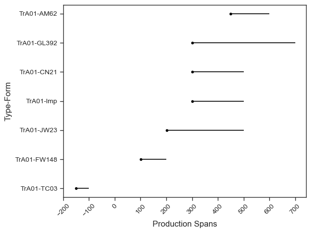

```python
KAGC_FUN.DU_MCLS_TPQ_Plt(a603, "N",  "A603_MCLS_TPQ_F_7_13",  ".pdf", start = -200, stop =800)
```

```python
a603.FCounts()[a603.FCounts().mcls=="fw"]
```

| col_0 | index | DU | mcls | diag | date3 | date4 | Dspan | MPDate | EAAD | idn | freq | Seq |
| --- | --- | --- | --- | --- | --- | --- | --- | --- | --- | --- | --- | --- |
| 48 | 48 | A603 | fw | classical-hellenistic black glaze | -500.0 | -201.0 | 299.0 | -350.5 | 950.0 | fw-classical-hellenistic black glaze--500.0--201.0 | 2 | 49 |
| 49 | 66 | A603 | fw | hellenistic color coated | -300.0 | -101.0 | 199.0 | -200.5 | 750.0 | fw-hellenistic color coated--300.0--101.0 | 18 | 50 |
| 50 | 67 | A603 | fw | hellenistic inturned rim bowl | -300.0 | -101.0 | 199.0 | -200.5 | 750.0 | fw-hellenistic inturned rim bowl--300.0--101.0 | 1 | 51 |
| 51 | 68 | A603 | fw | megarian bowl | -225.0 | -50.0 | 175.0 | -137.5 | 675.0 | fw-megarian bowl--225.0--50.0 | 1 | 52 |
| 52 | 65 | A603 | fw | eastern sigillata a form 22 | -200.0 | 10.0 | 210.0 | -95.0 | 650.0 | fw-eastern sigillata a form 22--200.0-10.0 | 7 | 53 |
| 53 | 64 | A603 | fw | eastern sigillata a | -150.0 | 200.0 | 350.0 | 25.0 | 600.0 | fw-eastern sigillata a--150.0-200.0 | 5 | 54 |
| 54 | 49 | A603 | fw | cypriot sigillata | -100.0 | 200.0 | 300.0 | 50.0 | 550.0 | fw-cypriot sigillata--100.0-200.0 | 6 | 55 |
| 55 | 63 | A603 | fw | early roman red slip, local | -100.0 | 200.0 | 300.0 | 50.0 | 550.0 | fw-early roman red slip, local--100.0-200.0 | 12 | 56 |
| 56 | 54 | A603 | fw | cypriot sigillata form p22 | -50.0 | 50.0 | 100.0 | 0.0 | 500.0 | fw-cypriot sigillata form p22--50.0-50.0 | 2 | 57 |
| 57 | 56 | A603 | fw | cypriot sigillata form p28 | 1.0 | 100.0 | 99.0 | 50.5 | 449.0 | fw-cypriot sigillata form p28-1.0-100.0 | 1 | 58 |
| 58 | 50 | A603 | fw | cypriot sigillata form p11 | 50.0 | 200.0 | 150.0 | 125.0 | 400.0 | fw-cypriot sigillata form p11-50.0-200.0 | 2 | 59 |
| 59 | 52 | A603 | fw | cypriot sigillata form p12 | 50.0 | 150.0 | 100.0 | 100.0 | 400.0 | fw-cypriot sigillata form p12-50.0-150.0 | 4 | 60 |
| 60 | 51 | A603 | fw | cypriot sigillata form p11 | 51.0 | 200.0 | 149.0 | 125.5 | 399.0 | fw-cypriot sigillata form p11-51.0-200.0 | 5 | 61 |
| 61 | 53 | A603 | fw | cypriot sigillata form p12 | 51.0 | 150.0 | 99.0 | 100.5 | 399.0 | fw-cypriot sigillata form p12-51.0-150.0 | 2 | 62 |
| 62 | 62 | A603 | fw | cypriot sigillata form p40 | 75.0 | 150.0 | 75.0 | 112.5 | 375.0 | fw-cypriot sigillata form p40-75.0-150.0 | 15 | 63 |
| 63 | 57 | A603 | fw | cypriot sigillata form p29 | 100.0 | 150.0 | 50.0 | 125.0 | 350.0 | fw-cypriot sigillata form p29-100.0-150.0 | 3 | 64 |
| 64 | 59 | A603 | fw | cypriot sigillata form p30 | 100.0 | 200.0 | 100.0 | 150.0 | 350.0 | fw-cypriot sigillata form p30-100.0-200.0 | 3 | 65 |
| 65 | 61 | A603 | fw | cypriot sigillata form p31 | 100.0 | 200.0 | 100.0 | 150.0 | 350.0 | fw-cypriot sigillata form p31-100.0-200.0 | 1 | 66 |
| 66 | 55 | A603 | fw | cypriot sigillata form p22b | 101.0 | 200.0 | 99.0 | 150.5 | 349.0 | fw-cypriot sigillata form p22b-101.0-200.0 | 1 | 67 |
| 67 | 58 | A603 | fw | cypriot sigillata form p29 | 101.0 | 150.0 | 49.0 | 125.5 | 349.0 | fw-cypriot sigillata form p29-101.0-150.0 | 1 | 68 |
| 68 | 60 | A603 | fw | cypriot sigillata form p30 | 101.0 | 200.0 | 99.0 | 150.5 | 349.0 | fw-cypriot sigillata form p30-101.0-200.0 | 1 | 69 |

```python
a603.FCounts()[a603.FCounts().mcls=="fw"].freq.sum()
```

```
93
```

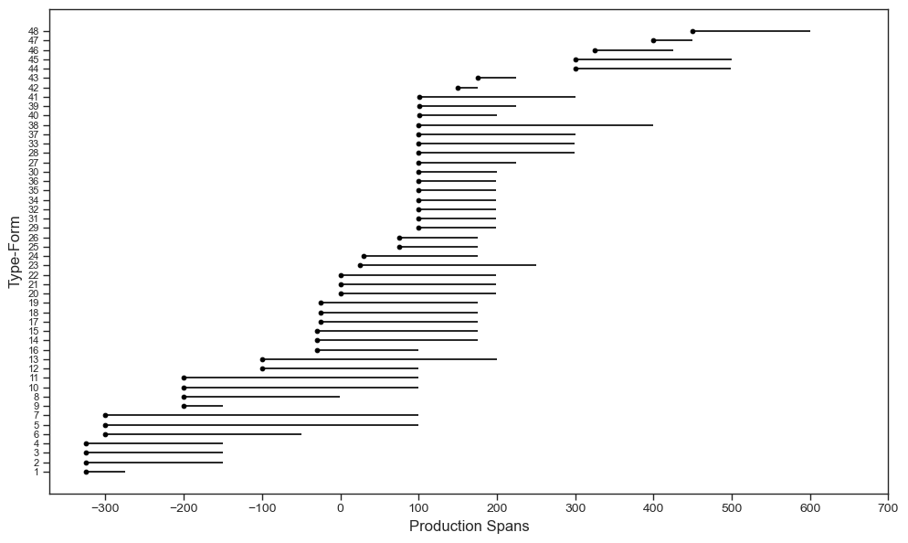

```python
KAGC_FUN.FC_DatePlt_Filtered(a603.FCounts()[a603.FCounts().mcls=="amp"], "", "", "", start = -300, stop = 800)
```

```python
a603.FCounts()[a603.FCounts().mcls=="amp"].diag.nunique()
```

```
25
```

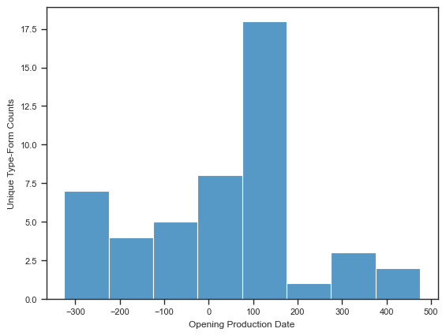

```python
sns.histplot(a603.FCounts()[a603.FCounts().mcls=="amp"].date3, binwidth=100)
plt.ylabel("Unique Type-Form Counts")
plt.xlabel("Opening Production Date")
```

```python
a603.FCounts()[a603.FCounts().mcls == "amp"].freq.sum()
```

```
95
```

```python
a603.FCounts()[a603.FCounts().mcls=="amp"].diag.nunique()
```

```
25
```

```python
a603.FCounts()[(a603.FCounts().mcls=="amp") & (a603.FCounts().date3.between(400, 500))].diag.nunique()
```

```
1
```

```python
a603.FCounts()[(a603.FCounts().mcls=="amp")].diag.count()
```

```
48
```

```python
a603.ResidualForms()[a603.ResidualForms().mcls == "amp"].diag.unique()
```

```
array(['TR-DBH', 'Rhodian stamped handle', 'Kouriote', 'Knidian amphora',
       'UnID-Kouriote', 'UnID', 'Koan-style', 'Imitation Koan-style',
       'PSEUDO-KOS-EN-CLOCHE', 'Knidos?', 'Rodos'], dtype=object)
```

```python
a603.cdu.type3.unique()
```

```
array(['p.adornment', 'special purpose', None, 'illumination', 'p.item',
       'tool', 'architectural', 'transport-storage', 'storage-processing',
       'vessel', 'tableware', 'ung', 'utensil', 'production', 'UnID',
       'display'], dtype=object)
```

### Marker Groups

```python
a603.MKG1()
```

| type1 cxn | architectural member | knife? | loom weight | mortar | mortarium | moulding | nail | painted plaster | revetment | suspension weight | suspension weight? | windowpane | windowpane? | All |
| --- | --- | --- | --- | --- | --- | --- | --- | --- | --- | --- | --- | --- | --- | --- |
| TRA01-2 | 1 | 1 | 1 | 1 | 1 | 1 | 17 | 33 | 2 | 1 | 2 | 2 | 2 | 65 |
| All | 1 | 1 | 1 | 1 | 1 | 1 | 17 | 33 | 2 | 1 | 2 | 2 | 2 | 65 |

```python
a603.MKG2()
```

| type1 cxn | coin | figurine | incense burner | ring | stand-base | All |
| --- | --- | --- | --- | --- | --- | --- |
| TRA01-2 | 2 | 3 | 1 | 2 | 1 | 9 |
| All | 2 | 3 | 1 | 2 | 1 | 9 |

```python
a603.MKG3()
```

| type1 cxn | AMRIT 77 | Agora G199 | Agora G199? | Beirut 3.3 | Bowl | Carrot Shape | Carrot small | Dressel 43 | Imitation Koan-style | Jug | Knidian amphora | Knidos? | Koan-style | Kouriate | Kouriote amphora | LRA 1 | LRA 4 | Mau 27/28 | Oval-section | PSEUDO-KOS-EN-CLOCHE | Phoenician style AM | Pompei 5 | Pompei 5? | Pseudo-Kos? | Ras al. Basit type | Rodos | TR-DBH | UnID | aryballos? | … |
| --- | --- | --- | --- | --- | --- | --- | --- | --- | --- | --- | --- | --- | --- | --- | --- | --- | --- | --- | --- | --- | --- | --- | --- | --- | --- | --- | --- | --- | --- | --- |
| TRA01-2 | 11 | 2 | 1 | 1 | 2 | 4 | 1 | 1 | 1 | 1 | 1 | 1 | 2 | 2 | 5 | 3 | 3 | 17 | 1 | 5 | 1 | 1 | 1 | 1 | 1 | 1 | 5 | 46 | 2 | … |
| All | 11 | 2 | 1 | 1 | 2 | 4 | 1 | 1 | 1 | 1 | 1 | 1 | 2 | 2 | 5 | 3 | 3 | 17 | 1 | 5 | 1 | 1 | 1 | 1 | 1 | 1 | 5 | 46 | 2 | … |

### Faunal Remains

```python
a603f = co.Faunal(art_db, KAGC_DUS.A603, "A603")
```

```python
a603f.BBW()
```

|  | index | name | tr_tb | area | level | species | bone | cond | burnt | butchered | worked | freq | Comment | cxn | DU |
| --- | --- | --- | --- | --- | --- | --- | --- | --- | --- | --- | --- | --- | --- | --- | --- |
| 181 | 181.0 | TRA01 | TR | A | 2 | ovis-capra | shaft | f | n | y | n | 1.0 | None | TRA01-2 | A603 |
| 183 | 183.0 | TRA01 | TR | A | 2 | ovis-capra | pelvis | f | y | y | n | 6.0 | None | TRA01-2 | A603 |
| 185 | 185.0 | TRA01 | TR | A | 2 | ovis-capra | tibia | f | n | y | n | 4.0 | Mni: 3 | TRA01-2 | A603 |
| 191 | 191.0 | TRA01 | TR | A | 2 | ovis-capra | distal metacarpus | f | n | y | n | 3.0 | None | TRA01-2 | A603 |
| 213 | 213.0 | TRA01 | TR | A | 2 | ovis-capra/sus | rib | I | n | y | n | 27.0 | None | TRA01-2 | A603 |
| 219 | 219.0 | TRA01 | TR | A | 2 | bos | proximal humus | I | n | y | n | 1.0 | None | TRA01-2 | A603 |
| 220 | 220.0 | TRA01 | TR | A | 2 | bos | distal humerus | I | n | y | n | 1.0 | None | TRA01-2 | A603 |
| 221 | 221.0 | TRA01 | TR | A | 2 | bos | humerus shaft | f | n | y | n | 1.0 | None | TRA01-2 | A603 |
| 223 | 223.0 | TRA01 | TR | A | 2 | bos | pelvis | f | n | y | n | 1.0 | None | TRA01-2 | A603 |
| 225 | 225.0 | TRA01 | TR | A | 2 | bos | distal femur | f | n | y | n | 1.0 | None | TRA01-2 | A603 |
| 226 | 226.0 | TRA01 | TR | A | 2 | bos | distal femur | f | n | y | n | 1.0 | None | TRA01-2 | A603 |
| 227 | 227.0 | TRA01 | TR | A | 2 | bos | distal femur | f | n | y | n | 1.0 | None | TRA01-2 | A603 |
| 230 | 230.0 | TRA01 | TR | A | 2 | bos | astragalus | f | n | y | n | 4.0 | all butchered | TRA01-2 | A603 |
| 231 | 231.0 | TRA01 | TR | A | 2 | bos | naviculocuboid | I | n | y | n | 1.0 | None | TRA01-2 | A603 |
| 232 | 232.0 | TRA01 | TR | A | 2 | bos | carpus-tarsus | I | n | y | n | 1.0 | None | TRA01-2 | A603 |
| 233 | 233.0 | TRA01 | TR | A | 2 | bos | proximal metatarsus | I | n | n | y | 1.0 | bone working | TRA01-2 | A603 |
| 234 | 234.0 | TRA01 | TR | A | 2 | bos | proximal metapodial | I | n | y | n | 3.0 | cut down length | TRA01-2 | A603 |
| 236 | 236.0 | TRA01 | TR | A | 2 | bos | Distal metapodial shaft | I | n | y | n | 1.0 | cut down length | TRA01-2 | A603 |
| 237 | 237.0 | TRA01 | TR | A | 2 | bos | metapodial shaft | f | n | y | n | 1.0 | cut down length | TRA01-2 | A603 |
| 242 | 242.0 | TRA01 | TR | A | 2 | bos | vertebra | I | n | y | n | 1.0 | None | TRA01-2 | A603 |
| 275 | 275.0 | TRA01 | TR | A | 2 | unid | fragm | f | y | None | None | 8.0 | None | TRA01-2 | A603 |

```python
a603f.BBWR()
```

```
14.07
```

```python
a603f.BBW().freq.sum()
```

```
69.0
```

```python
a603f.FxTB()
```

| species cxn | bos | bos/equus | canis | equus asinus | equus caballus | fish | gallus | lepus | ovis-capra | ovis-capra/sus | sus | unid | All |
| --- | --- | --- | --- | --- | --- | --- | --- | --- | --- | --- | --- | --- | --- |
| TRA01-2 | 112.0 | 17.0 | 6.0 | 2.0 | 11.0 | 4.0 | 19.0 | 1.0 | 127.0 | 77.0 | 31.0 | 633.0 | 1040.0 |
| All | 112.0 | 17.0 | 6.0 | 2.0 | 11.0 | 4.0 | 19.0 | 1.0 | 127.0 | 77.0 | 31.0 | 633.0 | 1040.0 |

### Trench TrA01 Baulk Trimming

```python
TRA1_BLK = df.loc[(df.cxn.isin(KAGC_DUS.blk)) & (df.name.str.contains('TRA01')) & (df.mcls=='fw')]
TRA1_BLK['MPDate'] = TRA1_BLK.loc[:, 'date3':'date4'].apply(np.median, axis = 1)
```

```python
TRA1_BLK.head()
```

|  | index | area | name | tb.tr | cxn | mcls | number | diag | Cat | date1 | date2 | date3 | date4 | type1 | type2 | type3 | type4 | type5 | type6 | cond | burnt | join | PL | PW | date5 | description | MPDate |
| --- | --- | --- | --- | --- | --- | --- | --- | --- | --- | --- | --- | --- | --- | --- | --- | --- | --- | --- | --- | --- | --- | --- | --- | --- | --- | --- | --- |
| 3131 | 60.0 | A | TRA01-BLK | TR | TRA01-BLK-0 | fw | 575 | classical-hellenistic black glaze | FW025 | BC | BC -500.0--201.0 | -500.0 | -201.0 | Fish Plate | rim/base | tableware | None | buff; fabric=7.5yr 7/4; slip=10yr 5/2 | None | frag | None | Y | 7.6 | 7.5 | late Cypro-Classical and early Hellenistic | horizontal drooping rim with ring foot. black slip. fish plate. joins with 591. | -350.5 |
| 3132 | 61.0 | A | TRA01-BLK | TR | TRA01-BLK-0 | fw | 707 | classical-hellenistic black glaze | None | BC | BC -500.0--201.0 | -500.0 | -201.0 | UnID | body | tableware | None | buff; fabric=7.5yr 7/6; slip=7.5yr 4/6 | None | frag | None | None | 4.6 | 3.5 | late Cypro-Classical and early Hellenistic | brown slip and two grooves. | -350.5 |
| 3133 | 62.0 | A | TRA01-BLK | TR | TRA01-BLK-0 | fw | 710 | classical-hellenistic black glaze | FW026 | BC | BC -500.0--201.0 | -500.0 | -201.0 | Plate | body | tableware | None | pink; fabric=5yr 8/4 | None | frag | None | None | 3.3 | 1.7 | late Cypro-Classical and early Hellenistic | same plate as 878. attic import. | -350.5 |
| 3135 | 64.0 | A | TRA01-BLK | TR | TRA01-BLK-0 | fw | 878 | classical-hellenistic black glaze | FW028 | BC | BC -500.0--201.0 | -500.0 | -201.0 | Plate | base | tableware | None | pink; fabric=5yr 8/4 | None | frag | None | None | 7 | 5 | late Cypro-Classical and early Hellenistic | flat base with black slip and stamped rosette and palmette. attic import. | -350.5 |
| 3179 | 108.0 | A | TRA01-BLK | TR | TRA01-BLK-0 | fw | 527 | cypriot sigillata | None | BC-AD | BC-AD -100.0-200.0 | -100.0 | 200.0 | UnID | base | tableware | None | pink; fabric=10r 8/4; slip=10r 2.5/2 | None | frag | None | None | 8.1 | 5 | Late Hellenistic to Early Roman | low ring foot with brown slip. | 50.0 |

```python
TRA1_BLK.MPDate.mean()
```

```
-24.416666666666668
```

```python
TRA1_BLK.date3.max()
```

```
101.0
```

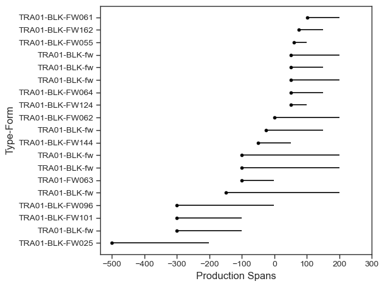

```python
KAGC_FUN.dateplot(df = TRA1_BLK,save_plot="N", out_ti="TRA01_BLK", fext=".png", start = -500, stop = 400)
```

```python
TRA1_BLK.diag.unique()
```

```
array(['classical-hellenistic black glaze', 'cypriot sigillata',
       'cypriot sigillata form p10', 'cypriot sigillata form p11',
       'cypriot sigillata form p22a', 'cypriot sigillata form p40',
       'cypriot sigillata form p9', 'early roman red slip, local',
       'eastern sigillata a', 'eastern sigillata a form 50',
       'eastern sigillata a form 59', 'eastern sigillata a form 64',
       'eastern sigillata b', 'eastern sigillata b form 60',
       'hellenistic color coated', 'hellenistic fine ware',
       'hellenistic inturned rim bowl', 'lamp, ancient-historic'],
      dtype=object)
```

```python
TRA1_BLK.diag.nunique()
```

```
18
```

```python
#KAGC_FUN.dateplot(df = a603.MCLS_Grps().get_group("fw"), save_plot="N", out_ti="A603_FW", fext=".png")
```

```python
a603.MCLS_Grps().get_group("fw").MPDate.mean()
```

```
3.5483870967741935
```

```python
a603.MCLS_Grps().get_group("amp").diag.unique()
```

```
array(['Dressel 43', 'Mau 27/28', 'PSEUDO-KOS-EN-CLOCHE', 'TR-DBH',
       'Oval-section', 'Rhodian stamped handle', 'Kouriote', 'LRA 4',
       'UnID', 'LRA 1', 'Pompei 5?', 'AMRIT 77', 'Agora G199',
       'Knidian amphora', 'UnID-Kouriote', 'Koan-style',
       'Imitation Koan-style', 'Ras al. Basit type', 'Beirut 3.3',
       'Pompei 5', 'Carrot Shape', 'Carrot small', 'Knidos?', 'Rodos',
       'Pseudo-Kos?'], dtype=object)
```

```python
len(a603.MCLS_Grps().get_group("amp").diag.unique())
```

```
25
```

```python
a603.MCLS_Grps().get_group("amp").date3.max()
```

```
450.0
```

```python
a603.MCLS_Grps().get_group("gls").type1.unique()
```

```
array(['bottle or jar', 'bowl', 'undiagnostic', 'beaker', 'dish or bowl',
       'aryballos?', 'rod', 'cup or shallow bowl', None, 'unguentarium',
       'plate', 'jug or bottle', 'windowpane', 'jug', 'cup',
       'windowpane?', 'cup or bowl', 'jar', 'cup or beaker',
       'beaker/bowl', 'indented beaker', 'ribbed bowl', 'bottle',
       'bowl or lamp', 'dish or shallow bowl', 'unguentarium?',
       'bottle or jug', 'beaker or unguentarium'], dtype=object)
```

```python
a603.MCLS_Grps().get_group("fw").diag.nunique()
```

```
18
```

```python
#KAGC_FUN.CommonSubtypes(a603.MCLS_Grps().get_group("fw").diag.unique(), TRA1_BLK.diag.unique())
```

## DU A009

```python
a009 = co.Context(KAGC_FUN.DU_Select(df, KAGC_DUS.A009, 'A009'), -24)
```

```python
len(KAGC_DUS.A009)
```

```
12
```

### Cat Nos

```python
a009.DUCatNos()
```

|  | cxn | mcls | diag | Cat | type1 | date3 | date4 |
| --- | --- | --- | --- | --- | --- | --- | --- |
| 1856 | TRA01-EE-037 | amp | Koan-style | AM20 | Koan-style | -25.0 | 175.0 |
| 1855 | TRA01-EE-037 | amp | Koan-style | AM22 | Koan-style | -25.0 | 175.0 |
| 1884 | TRA01-EE-043 | amp | Koan-style | AM23 | Koan-style | -25.0 | 175.0 |
| 1865 | TRA01-EE-038 | amp | Koan-style | AM24 | Koan-style | -25.0 | 175.0 |
| 1877 | TRA01-EE-043 | amp | Imitation Koan-style | AM26 | Imitation Koan-style | 1.0 | 199.0 |
| 1878 | TRA01-EE-043 | amp | Imitation Koan-style | AM27 | Imitation Koan-style | 1.0 | 199.0 |
| 1857 | TRA01-EE-037 | amp | AMRIT 77 | AM28 | AMRIT 77 | 100.0 | 225.0 |
| 1880 | TRA01-EE-043 | amp | AMRIT 77 | AM29 | AMRIT 77 | 100.0 | 225.0 |
| 1888 | TRA01-EE-048 | amp | PSEUDO-KOS-EN-CLOCHE | AM37 | PSEUDO-KOS-EN-CLOCHE | 75.0 | 175.0 |
| 1859 | TRA01-EE-037 | amp | Pompei 5 | AM39 | Pompei 5 | 50.0 | 125.0 |
| 1864 | TRA01-EE-039 | amp | Kouriote | AM44 | UnID | 1.0 | 199.0 |
| 1870 | TRA01-EE-038 | amp | Kouriote | AM45 | Kourite | 1.0 | 199.0 |
| 1875 | TRA01-EE-041 | amp | Agora G199 | AM48 | Agora G199 | 101.0 | 225.0 |
| 1876 | TRA01-EE-042 | amp | Agora G199 | AM49 | Agora G199 | 101.0 | 225.0 |
| 1861 | TRA01-EE-037 | amp | Agora G199 | AM52 | Agora G199 | 101.0 | 225.0 |
| 1882 | TRA01-EE-043 | amp | Agora G199 | AM53 | Agora G199 | 101.0 | 225.0 |
| 1886 | TRA01-EE-047 | amp | Agora G199 | AM54 | Agora G199 | 101.0 | 225.0 |
| 1885 | TRA01-EE-047 | amp | Africana 1 Piccolo | AM58 | Africana 1 Piccolo | 101.0 | 300.0 |
| 1879 | TRA01-EE-043 | amp | UnID | AM69 | UnID | 1.0 | 200.0 |
| 1869 | TRA01-EE-038 | amp | UnID | AM72 | UnID | 1.0 | 200.0 |
| 1872 | TRA01-EE-041 | amp | UnID | AM81 | UnID | 1.0 | 200.0 |
| 1883 | TRA01-EE-043 | amp | UnID | AM96 | UnID | NaN | NaN |
| 3106 | TRA01-EE-047 | fw | classical-hellenistic black glaze | FW016 | bowl | -500.0 | -201.0 |
| 3434 | TRA01-EE-037 | fw | hellenistic color coated | FW067 | Bowl | -300.0 | -101.0 |
| 3439 | TRA01-EE-048 | fw | hellenistic color coated | FW068 | UnID | -300.0 | -101.0 |
| 3440 | TRA01-EE-048 | fw | hellenistic color coated | FW069 | UnID | -300.0 | -101.0 |
| 3441 | TRA01-EE-048 | fw | hellenistic color coated | FW070 | UnID | -300.0 | -101.0 |
| 3442 | TRA01-EE-048 | fw | hellenistic color coated | FW071 | Bowl | -300.0 | -101.0 |
| 3288 | TRA01-EE-037 | fw | cypriot sigillata form p41 | FW172 | Bowl | 100.0 | 200.0 |
| 3527 | TRA01-EE-047 | stn | None | ST01 | altar | NaN | NaN |
| 3592 | TRA01-EE-048 | stn | None | ST29 | revetment | NaN | NaN |
| 3532 | TRA01-EE-037 | stn | None | ST34 | architectural member | NaN | NaN |
| 3540 | TRA01-EE-043 | stn | None | ST35 | moulding-arch | NaN | NaN |

#### Median Dates

```python
KAGC_FUN.MMDate(a009)
```

|  | mcls | MPDate |
| --- | --- | --- |
| 0 | amp | 135.578125 |
| 1 | fw | -178.222222 |
| 2 | gls | 244.187500 |
| 3 | lmp | 88.000000 |
| 4 | num | 400.500000 |
| 5 | pls | NaN |
| 6 | stn | NaN |

```python
a009.cdu.MPDate.mean()
```

```
101.24038461538461
```

### MCLS TPQs

```python
a009.MCLS_TPQS()
```

|  | DU | name | cxn | mcls | Cat | diag | type1 | type2 | date1 | date3 | date4 | Dspan | MPDate | EAAD | EAAD-M |
| --- | --- | --- | --- | --- | --- | --- | --- | --- | --- | --- | --- | --- | --- | --- | --- |
| 1587 | A009 | TRA01-EE | TRA01-EE-048 | lmp | None | Vessberg 13/14? | lamp | lower part | AD | 51.0 | 200.0 | 149.0 | 125.5 | 250.0 | 375.0 |
| 3288 | A009 | TRA01-EE | TRA01-EE-037 | fw | FW172 | cypriot sigillata form p41 | Bowl | rim | AD | 100.0 | 200.0 | 100.0 | 150.0 | 201.0 | 350.5 |
| 1861 | A009 | TRA01-EE | TRA01-EE-037 | amp | AM52 | Agora G199 | Agora G199 | H | AD | 101.0 | 225.0 | 124.0 | 163.0 | 200.0 | 337.5 |
| 2906 | A009 | TRA01-EE | TRA01-EE-038 | gls | None | bowl | bowl | rim | AD | 301.0 | 700.0 | 399.0 | 500.5 | 0.0 | 0.0 |
| 1703 | A009 | TRA01-EE | TRA01-EE-047 | num | None | coin | coin | intact | AD | 301.0 | 500.0 | 199.0 | 400.5 | 0.0 | 100.0 |

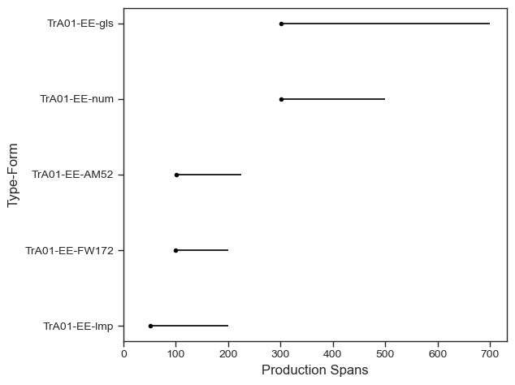

```python
KAGC_FUN.DU_MCLS_TPQ_Plt(a009, "Y", "Fig_7_10_A009_MCLS_TPQ", ".pdf", start= 0, stop= 800)
```

### FCounts

```python
a009.FCounts()[a009.FCounts().mcls=='fw']
```

| col_0 | index | DU | mcls | diag | date3 | date4 | Dspan | MPDate | EAAD | idn | freq | Seq |
| --- | --- | --- | --- | --- | --- | --- | --- | --- | --- | --- | --- | --- |
| 16 | 16 | A009 | fw | classical-hellenistic black glaze | -500.0 | -201.0 | 299.0 | -350.5 | 801.0 | fw-classical-hellenistic black glaze--500.0--201.0 | 1 | 17 |
| 17 | 18 | A009 | fw | hellenistic color coated | -300.0 | -101.0 | 199.0 | -200.5 | 601.0 | fw-hellenistic color coated--300.0--101.0 | 7 | 18 |
| 18 | 17 | A009 | fw | cypriot sigillata form p41 | 100.0 | 200.0 | 100.0 | 150.0 | 201.0 | fw-cypriot sigillata form p41-100.0-200.0 | 1 | 19 |

```python
a009.FCounts()[a009.FCounts().mcls=='amp'].diag.nunique()
```

```
13
```

```python
a009.FCounts()[a009.FCounts().mcls=="fw"].freq.sum()
```

```
9
```

```python
len(a009.cdu)
```

```
81
```

#### DUs A009 and 603 compared

In contrast, MG2 items are not well-represented in DU A009 or DU A603. They are limited to a few personal adornments (e.g., rings), personal items (e.g., coins), and special purpose items (e.g., terracotta figurine fragments and an incense burner fragment). Like DUs A020 and A019, the low frequency of personal items and adornments is consistent with what we might expect from items incorporated into these deposits through casual loss in a domestic context. Both DUs have a residual component consisting predominantly of Hellenistic and early Roman items with production dates earlier than 24 B.C. In DU A603, the ratio of non-residual to non-residual items is c. 3:1; in DU A009, it is c. 6:1. Both values are comparable to DU A019 and DU A020’s in neighboring TrA05.

While Depositional Units A009 and A603 follow the same broad trend, comparing components of their assemblage profiles, especially the amphorae, has given us some idea of how the cross-cutting in DU A603 likely conflated several dumping episodes, including the one that produced DU A009. Based on DU A009 and A603’s aggregate chronological and assemblage characteristics, we can broadly interpret them as admixtures of earthquake clean-up debris and post-quake municipal refuse. The residual items suggest that material derived from Hellenistic and Early Roman deposits, most likely from the Acropolis, also contributed to the waste streams that generated DUs A603 and A009. The comparatively high quantities of marble reduction waste, animal bone (including butchered and worked fragments), and transport/storage vessels indicate that domestic and commercial waste streams also played an essential role in shaping this sector of Area A’s stratigraphic biography. Like DUs A019 and A020, Marker Group 2 items are not well represented in DUs A009 and A603. Carbon buildup, sharp breaks, and in-context joins from DU A009 indicate that this material did not remain in the systemic context long before redeposition. Nevertheless, at some point after c. 450 A.D., DUs A009 and A603 entirely obscured the remaining parts of FA07 that had remained above ground to this point. Based on the available stratigraphic sections and photographs, it is clear that these deposits continue further to TrA01 and TrA01-EE’s south and east.

```python
a603amp = a603.FCounts()[a603.FCounts().mcls=="amp"].diag.unique()
a009amp = a009.FCounts()[a009.FCounts().mcls=='amp'].diag.unique()
```

```python
KAGC_FUN.CommonSubtypes(a603amp, a009amp)
```

```
{'Common subtypes:': {'AMRIT 77',
  'Agora G199',
  'Imitation Koan-style',
  'Koan-style',
  'Kouriote',
  'Mau 27/28',
  'PSEUDO-KOS-EN-CLOCHE',
  'Pompei 5',
  'UnID'},
 'Number of common subtypes:': 9}
```

```python
a603a = a603.FCounts()[a603.FCounts().mcls=="amp"].diag.unique().tolist()
```

```python
a603a
```

```
['Kouriote',
 'UnID',
 'UnID-Kouriote',
 'Knidos?',
 'Rodos',
 'Knidian amphora',
 'Rhodian stamped handle',
 'TR-DBH',
 'PSEUDO-KOS-EN-CLOCHE',
 'Imitation Koan-style',
 'Koan-style',
 'Oval-section',
 'Dressel 43',
 'Pseudo-Kos?',
 'AMRIT 77',
 'Carrot Shape',
 'Carrot small',
 'Mau 27/28',
 'Pompei 5',
 'Pompei 5?',
 'Agora G199',
 'Beirut 3.3',
 'Ras al. Basit type',
 'LRA 4',
 'LRA 1']
```

```python
len(a603a)
```

```
25
```

```python
a009a = a009.FCounts()[a009.FCounts().mcls=='amp'].diag.unique().tolist()
```

```python
a009a
```

```
['TR-BF-DBH',
 'Koan-style',
 'Imitation Koan-style',
 'Kouriote',
 'N. Lebanon type',
 'UnID',
 'Pompei 5',
 'PSEUDO-KOS-EN-CLOCHE',
 'AMRIT 77',
 'Mau 27/28',
 'UnID-CYP',
 'Africana 1 Piccolo',
 'Agora G199']
```

```python
len(a009a)
```

```
13
```

```python
a603_009_a = a603a + a009a
```

```python
a603_009_a
```

```
['Kouriote',
 'UnID',
 'UnID-Kouriote',
 'Knidos?',
 'Rodos',
 'Knidian amphora',
 'Rhodian stamped handle',
 'TR-DBH',
 'PSEUDO-KOS-EN-CLOCHE',
 'Imitation Koan-style',
 'Koan-style',
 'Oval-section',
 'Dressel 43',
 'Pseudo-Kos?',
 'AMRIT 77',
 'Carrot Shape',
 'Carrot small',
 'Mau 27/28',
 'Pompei 5',
 'Pompei 5?',
 'Agora G199',
 'Beirut 3.3',
 'Ras al. Basit type',
 'LRA 4',
 'LRA 1',
 'TR-BF-DBH',
 'Koan-style',
 'Imitation Koan-style',
 'Kouriote',
 'N. Lebanon type',
 'UnID',
 'Pompei 5',
 'PSEUDO-KOS-EN-CLOCHE',
 'AMRIT 77',
 'Mau 27/28',
 'UnID-CYP',
 'Africana 1 Piccolo',
 'Agora G199']
```

```python
tra01EA = np.unique(a603_009_a)
```

```python
tra01EA.tolist()
```

```
['AMRIT 77',
 'Africana 1 Piccolo',
 'Agora G199',
 'Beirut 3.3',
 'Carrot Shape',
 'Carrot small',
 'Dressel 43',
 'Imitation Koan-style',
 'Knidian amphora',
 'Knidos?',
 'Koan-style',
 'Kouriote',
 'LRA 1',
 'LRA 4',
 'Mau 27/28',
 'N. Lebanon type',
 'Oval-section',
 'PSEUDO-KOS-EN-CLOCHE',
 'Pompei 5',
 'Pompei 5?',
 'Pseudo-Kos?',
 'Ras al. Basit type',
 'Rhodian stamped handle',
 'Rodos',
 'TR-BF-DBH',
 'TR-DBH',
 'UnID',
 'UnID-CYP',
 'UnID-Kouriote']
```

```python
len(tra01EA)
```

```
29
```

```python
25*100/29
```

```
86.20689655172414
```

```python
13*100/29
```

```
44.827586206896555
```

```python
#KAGC_FUN.CommonSubtypes(a9fw, TRA1_BLK.diag.unique())
```

```python
#a009.cdu.date4.max() - a009.cdu.date3.min()
```

```python
a009.MKG1()
```

| type1 cxn | architectural member | architectural member? | marble "chips" | moulding | moulding-arch | moulding/capital | painted plaster | revetment | All |
| --- | --- | --- | --- | --- | --- | --- | --- | --- | --- |
| TRA01-EE-037 | 1 | 1 | 0 | 0 | 0 | 0 | 0 | 0 | 2 |
| TRA01-EE-038 | 0 | 0 | 0 | 1 | 0 | 1 | 0 | 0 | 2 |
| TRA01-EE-039 | 0 | 0 | 1 | 0 | 0 | 0 | 0 | 0 | 1 |
| TRA01-EE-042 | 0 | 1 | 0 | 0 | 0 | 0 | 0 | 0 | 1 |
| TRA01-EE-043 | 1 | 0 | 0 | 0 | 1 | 0 | 0 | 1 | 3 |
| TRA01-EE-047 | 0 | 0 | 0 | 2 | 0 | 0 | 0 | 0 | 2 |
| TRA01-EE-048 | 0 | 0 | 0 | 0 | 0 | 0 | 0 | 1 | 1 |
| TRA01-EE-049 | 0 | 0 | 0 | 0 | 0 | 0 | 1 | 0 | 1 |
| All | 2 | 2 | 1 | 3 | 1 | 1 | 1 | 2 | 13 |

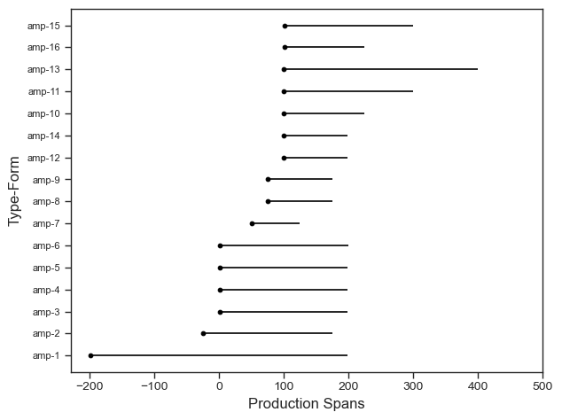

```python
KAGC_FUN.FC_DatePlt_Filtered(a009.FCounts()[a009.FCounts().mcls=="amp"], "", "", "", start = -200, stop = 600)
```

```python
a603.MKG1()
```

| type1 cxn | architectural member | knife? | loom weight | mortar | mortarium | moulding | nail | painted plaster | revetment | suspension weight | suspension weight? | windowpane | windowpane? | All |
| --- | --- | --- | --- | --- | --- | --- | --- | --- | --- | --- | --- | --- | --- | --- |
| TRA01-2 | 1 | 1 | 1 | 1 | 1 | 1 | 17 | 33 | 2 | 1 | 2 | 2 | 2 | 65 |
| All | 1 | 1 | 1 | 1 | 1 | 1 | 17 | 33 | 2 | 1 | 2 | 2 | 2 | 65 |

```python
a009.MKG1()
```

| type1 cxn | architectural member | architectural member? | marble "chips" | moulding | moulding-arch | moulding/capital | painted plaster | revetment | All |
| --- | --- | --- | --- | --- | --- | --- | --- | --- | --- |
| TRA01-EE-037 | 1 | 1 | 0 | 0 | 0 | 0 | 0 | 0 | 2 |
| TRA01-EE-038 | 0 | 0 | 0 | 1 | 0 | 1 | 0 | 0 | 2 |
| TRA01-EE-039 | 0 | 0 | 1 | 0 | 0 | 0 | 0 | 0 | 1 |
| TRA01-EE-042 | 0 | 1 | 0 | 0 | 0 | 0 | 0 | 0 | 1 |
| TRA01-EE-043 | 1 | 0 | 0 | 0 | 1 | 0 | 0 | 1 | 3 |
| TRA01-EE-047 | 0 | 0 | 0 | 2 | 0 | 0 | 0 | 0 | 2 |
| TRA01-EE-048 | 0 | 0 | 0 | 0 | 0 | 0 | 0 | 1 | 1 |
| TRA01-EE-049 | 0 | 0 | 0 | 0 | 0 | 0 | 1 | 0 | 1 |
| All | 2 | 2 | 1 | 3 | 1 | 1 | 1 | 2 | 13 |

```python
a009.cdu[a009.cdu.type1 == "moulding"]
```

|  | index | area | name | tb.tr | cxn | mcls | number | diag | Cat | date1 | date2 | date3 | date4 | type1 | type2 | type3 | type4 | type5 | type6 | cond | burnt | join | PL | PW | date5 | description | DU | MPDate | idn | … |
| --- | --- | --- | --- | --- | --- | --- | --- | --- | --- | --- | --- | --- | --- | --- | --- | --- | --- | --- | --- | --- | --- | --- | --- | --- | --- | --- | --- | --- | --- | --- |
| 3857 | NaN | A | TRA01-EE | TR | TRA01-EE-038 | pls | 1027 | None | None | None | None | NaN | NaN | moulding | fragment | architectural | None | None | None | None | None | None | None | None | None | None | A009 | NaN | pls-UnID-nan-nan | … |
| 3859 | NaN | A | TRA01-EE | TR | TRA01-EE-047 | pls | 1031 | None | None | None | None | NaN | NaN | moulding | fragment | architectural | None | None | None | None | None | None | None | None | None | None | A009 | NaN | pls-UnID-nan-nan | … |
| 3860 | NaN | A | TRA01-EE | TR | TRA01-EE-047 | pls | 1032 | None | None | None | None | NaN | NaN | moulding | fragment | architectural | None | None | None | None | None | None | None | None | None | None | A009 | NaN | pls-UnID-nan-nan | … |

```python
a009.cdu.type1.unique()
```

```
array(['lamp', 'coin', 'Koan-style', 'AMRIT 77', 'TR-BF-DBH', 'Pompei 5',
       'Agora G199', 'UnID', 'Mau 27/28', 'Kourite', 'N. Lebanon type',
       None, 'Imitation Koan-style', 'UnID-CYP', 'Africana 1 Piccolo',
       'PSEUDO-KOS-EN-CLOCHE', 'undiagnostic', 'cup or bowl', 'bowl',
       'unguentarium', 'Bowl', 'altar', 'architectural member',
       'moulding-arch', 'revetment', 'architectural member?',
       'marble "chips"', 'unid', 'moulding', 'moulding/capital',
       'painted plaster'], dtype=object)
```

```python
a009.FCounts().MPDate.mean()
```

```
131.30769230769232
```

```python
a009.DUSmry()
```

|  | DU | TPQ | MMDate | Span | TForms | RForms | NRForms | NRF:RF | Dspan > 100 | Arch | Display | P.items | P.adorn | Tool | Production |
| --- | --- | --- | --- | --- | --- | --- | --- | --- | --- | --- | --- | --- | --- | --- | --- |
| 0 | A009 | 301.0 | 101 | 1200.0 | 26 | 4 | 22 | 5.5 | 19 | True | True | True | False | False | False |

```python
a009f = co.Faunal(art_db, KAGC_DUS.A009, "A009")
```

```python
a009f.faun()
```

|  | index | name | tr_tb | area | level | species | bone | cond | burnt | butchered | worked | freq | Comment | cxn | DU |
| --- | --- | --- | --- | --- | --- | --- | --- | --- | --- | --- | --- | --- | --- | --- | --- |
| 323 | 323.0 | TRA01-EE | TR | A | 037 | ovis-capra-sized | rib | f | n | n | n | 2.0 | None | TRA01-EE-037 | A009 |
| 324 | 324.0 | TRA01-EE | TR | A | 037 | ovis-capra-sized | fragm | f | n | n | n | 4.0 | None | TRA01-EE-037 | A009 |
| 325 | 325.0 | TRA01-EE | TR | A | 037 | bos-sized | shaft | f | n | y | n | 1.0 | None | TRA01-EE-037 | A009 |
| 326 | 326.0 | TRA01-EE | TR | A | 037 | bos-sized | shaft | f | n | n | n | 1.0 | None | TRA01-EE-037 | A009 |
| 327 | 327.0 | TRA01-EE | TR | A | 037 | unid | fragm | f | n | n | n | 3.0 | None | TRA01-EE-037 | A009 |
| 328 | 328.0 | TRA01-EE | TR | A | 039 | bos-sized | fragm | f | n | n | y | 6.0 | None | TRA01-EE-039 | A009 |
| 329 | 329.0 | TRA01-EE | TR | A | 039 | ?dama | antler | f | n | n | y | 5.0 | None | TRA01-EE-039 | A009 |
| 330 | 330.0 | TRA01-EE | TR | A | 041 | ovis-capra | shaft | f | n | n | n | 8.0 | None | TRA01-EE-041 | A009 |
| 331 | 331.0 | TRA01-EE | TR | A | 041 | ovis-capra | rib | f | n | n | n | 3.0 | None | TRA01-EE-041 | A009 |
| 332 | 332.0 | TRA01-EE | TR | A | 042 | ovis-capra | shaft | f | n | n | n | 1.0 | None | TRA01-EE-042 | A009 |
| 333 | 333.0 | TRA01-EE | TR | A | 042 | mammal | shaft | f | n | y | n | 1.0 | None | TRA01-EE-042 | A009 |
| 334 | 334.0 | TRA01-EE | TR | A | 042 | bos-sized | radius/ulna | f | n | n | n | 1.0 | None | TRA01-EE-042 | A009 |
| 335 | 335.0 | TRA01-EE | TR | A | 042 | gallus | humerus | f | n | n | n | 1.0 | None | TRA01-EE-042 | A009 |
| 336 | 336.0 | TRA01-EE | TR | A | 043 | sus | phalanx-2 | i | n | n | n | 1.0 | None | TRA01-EE-043 | A009 |
| 337 | 337.0 | TRA01-EE | TR | A | 043 | ovis-capra/sus | shaft | f | n | n | n | 1.0 | None | TRA01-EE-043 | A009 |
| 338 | 338.0 | TRA01-EE | TR | A | 046 | bos-sized | shaft | f | n | n | n | 14.0 | None | TRA01-EE-046 | A009 |
| 339 | 339.0 | TRA01-EE | TR | A | 047 | ovis-capra | shaft | f | n | n | n | 3.0 | None | TRA01-EE-047 | A009 |
| 340 | 340.0 | TRA01-EE | TR | A | 047 | ovis-capra | fragm | f | n | n | n | 12.0 | None | TRA01-EE-047 | A009 |
| 341 | 341.0 | TRA01-EE | TR | A | 047 | bos-sized | fragm | f | n | n | n | 1.0 | None | TRA01-EE-047 | A009 |
| 342 | 342.0 | TRA01-EE | TR | A | 048 | ovis-capra | molar | f | n | n | n | 1.0 | None | TRA01-EE-048 | A009 |
| 343 | 343.0 | TRA01-EE | TR | A | 048 | ovis-capra | shaft | f | n | n | n | 24.0 | None | TRA01-EE-048 | A009 |
| 344 | 344.0 | TRA01-EE | TR | A | 049 | ovis-capra | molar | f | n | n | n | 3.0 | None | TRA01-EE-049 | A009 |
| 345 | 345.0 | TRA01-EE | TR | A | 049 | ovis-capra | vertebra | f | n | n | n | 2.0 | None | TRA01-EE-049 | A009 |
| 346 | 346.0 | TRA01-EE | TR | A | 049 | ovis-capra | rib | f | n | n | n | 2.0 | None | TRA01-EE-049 | A009 |
| 347 | 347.0 | TRA01-EE | TR | A | 049 | bos | atlas | f | n | n | n | 1.0 | None | TRA01-EE-049 | A009 |
| 348 | 348.0 | TRA01-EE | TR | A | 049 | bos | shaft | f | n | n | n | 1.0 | None | TRA01-EE-049 | A009 |
| 349 | 349.0 | TRA01-EE | TR | A | 049 | unid | fragm | f | n | n | n | 13.0 | None | TRA01-EE-049 | A009 |
| 362 | 362.0 | TRA01-EE | TR | A | 053 | bos-sized | shaft | f | n | n | n | 9.0 | None | TRA01-EE-053 | A009 |

## DU A019

```python
a019 = co.Context(KAGC_FUN.DU_Select(df, KAGC_DUS.A019, 'A019'), -24)
```

### Cat Nos

```python
a019.DUCatNos()
```

|  | cxn | mcls | diag | Cat | type1 | date3 | date4 |
| --- | --- | --- | --- | --- | --- | --- | --- |
| 3487 | TRA05-2 | fw | hellenistic color coated | FW088 | Bowl | -300.0 | -101.0 |
| 3309 | TRA05-2 | fw | early roman red slip, local | FW182 | UnID | -100.0 | 200.0 |
| 3310 | TRA05-2 | fw | early roman red slip, local | FW183 | Bowl | -100.0 | 200.0 |
| 1529 | TRA05-2 | lmp | Vessberg 13 | LP17 | lamp | 101.0 | 300.0 |
| 1708 | TRA05-2.3 | num | Constantius II & Julian Augusti | CN26 | coin | 355.0 | 363.0 |
| 1709 | TRA05-2.3 | num | Valentinian II | CN27 | coin | 378.0 | 388.0 |
| 1710 | TRA05-2.3 | num | coin | CN28 | coin | 301.0 | 500.0 |
| 1711 | TRA05-2.3 | num | Arcadius & Honorius | CN29 | coin | 400.0 | 408.0 |
| 1712 | TRA05-2.3 | num | Honorius | CN30 | coin | 395.0 | 402.0 |
| 3783 | TRA05-2.1 | pls | None | PL33 | painted plaster | NaN | NaN |
| 3784 | TRA05-2.1 | pls | None | PL34 | painted plaster | NaN | NaN |
| 3785 | TRA05-2.1 | pls | None | PL35 | painted plaster | NaN | NaN |
| 3786 | TRA05-2 | pls | None | PL36 | painted plaster | NaN | NaN |
| 3787 | TRA05-2 | pls | None | PL37 | painted plaster | NaN | NaN |
| 3790 | TRA05-2 | pls | None | PL40 | painted plaster | NaN | NaN |
| 3792 | TRA05-2 | pls | None | PL42 | painted plaster | NaN | NaN |
| 3793 | TRA05-2 | pls | None | PL43 | painted plaster | NaN | NaN |
| 3794 | TRA05-2.1 | pls | None | PL44 | painted plaster | NaN | NaN |
| 3795 | TRA05-2.2 | pls | None | PL45 | painted plaster | NaN | NaN |

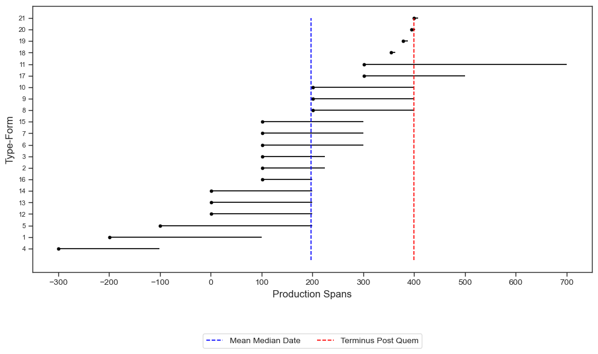

```python
KAGC_FUN.FC_DatePlt(df = a019, save_plot="Y", out_ti="Fig_7_8_A019", fext=".pdf", Vlines= "Y", start = -300, stop = 800)
```

## FCounts

```python
a019.FCounts()
```

| col_0 | index | DU | mcls | diag | date3 | date4 | Dspan | MPDate | EAAD | idn | freq | Seq |
| --- | --- | --- | --- | --- | --- | --- | --- | --- | --- | --- | --- | --- |
| 0 | 2 | A019 | amp | Rodos | -199.0 | 100.0 | 299.0 | -49.5 | 599.0 | amp-Rodos--199.0-100.0 | 1 | 1 |
| 1 | 0 | A019 | amp | AMRIT 77 | 101.0 | 225.0 | 124.0 | 163.0 | 299.0 | amp-AMRIT 77-101.0-225.0 | 1 | 2 |
| 2 | 1 | A019 | amp | Agora G199 | 101.0 | 225.0 | 124.0 | 163.0 | 299.0 | amp-Agora G199-101.0-225.0 | 2 | 3 |
| 3 | 4 | A019 | fw | hellenistic color coated | -300.0 | -101.0 | 199.0 | -200.5 | 700.0 | fw-hellenistic color coated--300.0--101.0 | 1 | 4 |
| 4 | 3 | A019 | fw | early roman red slip, local | -100.0 | 200.0 | 300.0 | 50.0 | 500.0 | fw-early roman red slip, local--100.0-200.0 | 2 | 5 |
| 5 | 6 | A019 | gls | cup or shallow bowl | 101.0 | 300.0 | 199.0 | 200.5 | 299.0 | gls-cup or shallow bowl-101.0-300.0 | 1 | 6 |
| 6 | 10 | A019 | gls | unguentarium | 101.0 | 300.0 | 199.0 | 200.5 | 299.0 | gls-unguentarium-101.0-300.0 | 1 | 7 |
| 7 | 5 | A019 | gls | bowl | 201.0 | 400.0 | 199.0 | 300.5 | 199.0 | gls-bowl-201.0-400.0 | 1 | 8 |
| 8 | 7 | A019 | gls | cup or small jar | 201.0 | 400.0 | 199.0 | 300.5 | 199.0 | gls-cup or small jar-201.0-400.0 | 1 | 9 |
| 9 | 8 | A019 | gls | flask or jar | 201.0 | 400.0 | 199.0 | 300.5 | 199.0 | gls-flask or jar-201.0-400.0 | 1 | 10 |
| 10 | 9 | A019 | gls | undiagnostic | 301.0 | 700.0 | 399.0 | 500.5 | 99.0 | gls-undiagnostic-301.0-700.0 | 1 | 11 |
| 11 | 11 | A019 | lmp | UnID | 1.0 | 200.0 | 199.0 | 100.5 | 399.0 | lmp-UnID-1.0-200.0 | 3 | 12 |
| 12 | 12 | A019 | lmp | Vessberg 11/14? | 1.0 | 200.0 | 199.0 | 100.5 | 399.0 | lmp-Vessberg 11/14?-1.0-200.0 | 1 | 13 |
| 13 | 14 | A019 | lmp | Vessberg 13/14? | 1.0 | 200.0 | 199.0 | 100.5 | 399.0 | lmp-Vessberg 13/14?-1.0-200.0 | 1 | 14 |
| 14 | 13 | A019 | lmp | Vessberg 13 | 101.0 | 300.0 | 199.0 | 200.5 | 299.0 | lmp-Vessberg 13-101.0-300.0 | 1 | 15 |
| 15 | 15 | A019 | lmp | Vessberg 15? | 101.0 | 200.0 | 99.0 | 150.5 | 299.0 | lmp-Vessberg 15?-101.0-200.0 | 1 | 16 |
| 16 | 20 | A019 | num | coin | 301.0 | 500.0 | 199.0 | 400.5 | 99.0 | num-coin-301.0-500.0 | 1 | 17 |
| 17 | 17 | A019 | num | Constantius II & Julian Augusti | 355.0 | 363.0 | 8.0 | 359.0 | 45.0 | num-Constantius II & Julian Augusti-355.0-363.0 | 1 | 18 |
| 18 | 19 | A019 | num | Valentinian II | 378.0 | 388.0 | 10.0 | 383.0 | 22.0 | num-Valentinian II-378.0-388.0 | 1 | 19 |
| 19 | 18 | A019 | num | Honorius | 395.0 | 402.0 | 7.0 | 398.5 | 5.0 | num-Honorius-395.0-402.0 | 1 | 20 |
| 20 | 16 | A019 | num | Arcadius & Honorius | 400.0 | 408.0 | 8.0 | 404.0 | 0.0 | num-Arcadius & Honorius-400.0-408.0 | 1 | 21 |

```python
print(tabulate(a019.FCounts()[["DU", "mcls", "diag", "date3", "date4", "Dspan", "MPDate", "EAAD", "Seq"]],
headers= ["DU", "Material Class", "Type", "Opening Date", "Closing Date", "Span", "Median Date", "EAAD", "Index"],showindex=False, tablefmt="pipe"))
```

```
| DU   | Material Class   | Type                            |   Opening Date |   Closing Date |   Span |   Median Date |   EAAD |   Index |
|:-----|:-----------------|:--------------------------------|---------------:|---------------:|-------:|--------------:|-------:|--------:|
| A019 | amp              | Rodos                           |           -199 |            100 |    299 |         -49.5 |    599 |       1 |
| A019 | amp              | AMRIT 77                        |            101 |            225 |    124 |         163   |    299 |       2 |
| A019 | amp              | Agora G199                      |            101 |            225 |    124 |         163   |    299 |       3 |
| A019 | fw               | hellenistic color coated        |           -300 |           -101 |    199 |        -200.5 |    700 |       4 |
| A019 | fw               | early roman red slip, local     |           -100 |            200 |    300 |          50   |    500 |       5 |
| A019 | gls              | cup or shallow bowl             |            101 |            300 |    199 |         200.5 |    299 |       6 |
| A019 | gls              | unguentarium                    |            101 |            300 |    199 |         200.5 |    299 |       7 |
| A019 | gls              | bowl                            |            201 |            400 |    199 |         300.5 |    199 |       8 |
| A019 | gls              | cup or small jar                |            201 |            400 |    199 |         300.5 |    199 |       9 |
| A019 | gls              | flask or jar                    |            201 |            400 |    199 |         300.5 |    199 |      10 |
| A019 | gls              | undiagnostic                    |            301 |            700 |    399 |         500.5 |     99 |      11 |
| A019 | lmp              | UnID                            |              1 |            200 |    199 |         100.5 |    399 |      12 |
| A019 | lmp              | Vessberg 11/14?                 |              1 |            200 |    199 |         100.5 |    399 |      13 |
| A019 | lmp              | Vessberg 13/14?                 |              1 |            200 |    199 |         100.5 |    399 |      14 |
| A019 | lmp              | Vessberg 13                     |            101 |            300 |    199 |         200.5 |    299 |      15 |
| A019 | lmp              | Vessberg 15?                    |            101 |            200 |     99 |         150.5 |    299 |      16 |
| A019 | num              | coin                            |            301 |            500 |    199 |         400.5 |     99 |      17 |
| A019 | num              | Constantius II & Julian Augusti |            355 |            363 |      8 |         359   |     45 |      18 |
| A019 | num              | Valentinian II                  |            378 |            388 |     10 |         383   |     22 |      19 |
| A019 | num              | Honorius                        |            395 |            402 |      7 |         398.5 |      5 |      20 |
| A019 | num              | Arcadius & Honorius             |            400 |            408 |      8 |         404   |      0 |      21 |
```

### MCLS TPQs

```python
a019.MCLS_Grps(). get_group("jwl")
```

|  | index | area | name | tb.tr | cxn | mcls | number | diag | Cat | date1 | date2 | date3 | date4 | type1 | type2 | type3 | type4 | type5 | type6 | cond | burnt | join | PL | PW | date5 | description | DU | MPDate | Dspan | … |
| --- | --- | --- | --- | --- | --- | --- | --- | --- | --- | --- | --- | --- | --- | --- | --- | --- | --- | --- | --- | --- | --- | --- | --- | --- | --- | --- | --- | --- | --- | --- |
| 75 | 75.0 | A | TRA05 | TR | TRA05-2.2 | jwl | TrAV/2.0 L2/4 | bead | None | UnID | UnID nan-nan | NaN | NaN | bead | None | p.adornment | None | None | faience? | intact | None | None | None | None | None | Intact; globular, vertical incised lines; l 1.1, w 5.8 | A019 | NaN | NaN | … |

```python
a019.MCLS_TPQS()
```

|  | DU | name | cxn | mcls | Cat | diag | type1 | type2 | date1 | date3 | date4 | Dspan | MPDate | EAAD | EAAD-M |
| --- | --- | --- | --- | --- | --- | --- | --- | --- | --- | --- | --- | --- | --- | --- | --- |
| 3309 | A019 | TRA05 | TRA05-2 | fw | FW182 | early roman red slip, local | UnID | handle | BC-AD | -100.0 | 200.0 | 300.0 | 50.0 | 500.0 | 450.5 |
| 3036 | A019 | TRA05 | TRA05-2.3 | amp | None | Agora G199 | Agora G199 | H | AD | 101.0 | 225.0 | 124.0 | 163.0 | 299.0 | 337.5 |
| 1523 | A019 | TRA05 | TRA05-2 | lmp | None | Vessberg 15? | lamp | handle | AD | 101.0 | 200.0 | 99.0 | 150.5 | 299.0 | 350.0 |
| 2691 | A019 | TRA05 | TRA05-2.1 | gls | None | undiagnostic | undiagnostic | rim/body | AD | 301.0 | 700.0 | 399.0 | 500.5 | 99.0 | 0.0 |
| 1711 | A019 | TRA05 | TRA05-2.3 | num | CN29 | Arcadius & Honorius | coin | intact | AD | 400.0 | 408.0 | 8.0 | 404.0 | 0.0 | 96.5 |

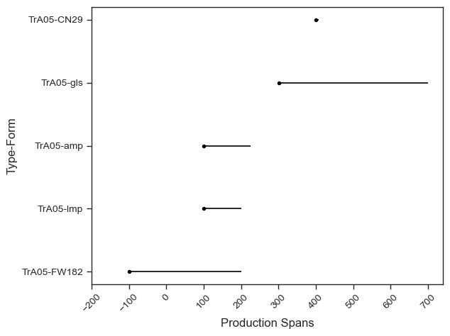

```python
KAGC_FUN.DU_MCLS_TPQ_Plt(a019, save_plot='N', out_ti=' ', fext=' ', start=-200, stop = 800)
```

#### Median Dates

```python
a009.cdu.MPDate.mean()
```

```
101.24038461538461
```

```python
KAGC_FUN.MMDate(a019)
```

|  | mcls | MPDate |
| --- | --- | --- |
| 0 | amp | 109.875000 |
| 1 | fw | -33.500000 |
| 2 | gls | 300.500000 |
| 3 | jwl | NaN |
| 4 | lmp | 121.928571 |
| 5 | mtl | NaN |
| 6 | num | 389.000000 |
| 7 | pls | NaN |
| 8 | stn | NaN |

### DU A019 Summary

```python
a019.DUSmry()
```

|  | DU | TPQ | MMDate | Span | TForms | RForms | NRForms | NRF:RF | Dspan > 100 | Arch | Display | P.items | P.adorn | Tool | Production |
| --- | --- | --- | --- | --- | --- | --- | --- | --- | --- | --- | --- | --- | --- | --- | --- |
| 0 | A019 | 400.0 | 198 | 1000.0 | 21 | 3 | 18 | 6.0 | 16 | True | True | True | True | False | False |

### Marker Groups

```python
a019.MKG1()
```

| type1 cxn | nail? | painted plaster | revetment | All |
| --- | --- | --- | --- | --- |
| TRA05-2 | 2 | 5 | 1 | 8 |
| TRA05-2.1 | 0 | 4 | 0 | 4 |
| TRA05-2.2 | 0 | 1 | 0 | 1 |
| TRA05-2.3 | 0 | 0 | 1 | 1 |
| All | 2 | 10 | 2 | 14 |

```python
a019.MKG2()
```

| type1 cxn | bead | coin | All |
| --- | --- | --- | --- |
| TRA05-2.2 | 1 | 0 | 1 |
| TRA05-2.3 | 0 | 5 | 5 |
| All | 1 | 5 | 6 |

```python
a019.MKG3()
```

| type1 cxn | AMRIT 77 | Agora G199 | Bowl | Rodos | UnID | cup or small jar | flask or jar | lamp | unguentarium | All |
| --- | --- | --- | --- | --- | --- | --- | --- | --- | --- | --- |
| TRA05-2 | 0 | 0 | 2 | 0 | 1 | 1 | 1 | 8 | 0 | 13 |
| TRA05-2.1 | 0 | 0 | 0 | 0 | 1 | 0 | 0 | 0 | 0 | 1 |
| TRA05-2.2 | 1 | 1 | 0 | 1 | 1 | 0 | 0 | 0 | 0 | 4 |
| TRA05-2.3 | 0 | 1 | 0 | 0 | 3 | 0 | 0 | 0 | 1 | 5 |
| All | 1 | 2 | 2 | 1 | 6 | 1 | 1 | 8 | 1 | 23 |

## Faunal

```python
a019F = co.Faunal(art_db, KAGC_DUS.A019, "A019")
```

```python
a019F.BBW()
```

|  | index | name | tr_tb | area | level | species | bone | cond | burnt | butchered | worked | freq | Comment | cxn | DU |
| --- | --- | --- | --- | --- | --- | --- | --- | --- | --- | --- | --- | --- | --- | --- | --- |
| 448 | 448.0 | TRA05 | TR | A | 2 | bos | shaft | f | n | n | y | 1.0 | None | TRA05-2 | A019 |
| 460 | 460.0 | TRA05 | TR | A | 2.2 | ovis-capra | vertebra | f | n | y | n | 1.0 | None | TRA05-2.2 | A019 |

```python
a019F.FxTB()
```

| species cxn | bird | bos | fish | mammal | ovis-capra | ovis-capra-sized | sus | unid | All |
| --- | --- | --- | --- | --- | --- | --- | --- | --- | --- |
| TRA05-2 | 3.0 | 8.0 | NaN | 8.0 | 6.0 | 1.0 | 1.0 | 3.0 | 30.0 |
| TRA05-2.1 | NaN | 1.0 | NaN | NaN | 1.0 | 1.0 | NaN | 1.0 | 4.0 |
| TRA05-2.2 | NaN | 5.0 | 1.0 | NaN | 8.0 | NaN | NaN | NaN | 14.0 |
| All | 3.0 | 14.0 | 1.0 | 8.0 | 15.0 | 2.0 | 1.0 | 4.0 | 48.0 |

## DU A020

```python
a020 = co.Context(KAGC_FUN.DU_Select(df, KAGC_DUS.A020, 'A020'), -24)
```

### Cat Nos

```python
a020.DUCatNos()
```

|  | cxn | mcls | diag | Cat | type1 | date3 | date4 |
| --- | --- | --- | --- | --- | --- | --- | --- |
| 2714 | TRA05-3.1 | gls | reshaped vessel | G17.158 | reshaped vessel | 401.0 | 700.0 |
| 2715 | TRA05-3.1 | gls | tessera | G17.158 | tessera | 200.0 | 700.0 |
| 3789 | TRA05-3.1 | pls | None | PL39 | painted plaster | NaN | NaN |
| 3797 | TRA05-3 | pls | None | PL47 | painted plaster | NaN | NaN |
| 3799 | TRA05-3 | pls | None | PL49 | moulding | NaN | NaN |
| 3597 | TRA05-3 | stn | None | ST10 | mortarium | NaN | NaN |
| 3624 | TRA05-3 | stn | None | ST22 | bowl | NaN | NaN |

### FCounts

```python
a020.FCounts()
```

| col_0 | index | DU | mcls | diag | date3 | date4 | Dspan | MPDate | EAAD | idn | freq | Seq |
| --- | --- | --- | --- | --- | --- | --- | --- | --- | --- | --- | --- | --- |
| 0 | 3 | A020 | amp | Kouriote? | -275.0 | -30.0 | 245.0 | -152.5 | 676.0 | amp-Kouriote?--275.0--30.0 | 1 | 1 |
| 1 | 4 | A020 | amp | TR-DBH | -75.0 | 175.0 | 250.0 | 50.0 | 476.0 | amp-TR-DBH--75.0-175.0 | 1 | 2 |
| 2 | 2 | A020 | amp | Egypt | -30.0 | 100.0 | 130.0 | 35.0 | 431.0 | amp-Egypt--30.0-100.0 | 1 | 3 |
| 3 | 0 | A020 | amp | AMRIT 77 | 101.0 | 225.0 | 124.0 | 163.0 | 300.0 | amp-AMRIT 77-101.0-225.0 | 2 | 4 |
| 4 | 1 | A020 | amp | Agora G199 | 101.0 | 225.0 | 124.0 | 163.0 | 300.0 | amp-Agora G199-101.0-225.0 | 2 | 5 |
| 5 | 9 | A020 | gls | undiagnostic | 101.0 | 300.0 | 199.0 | 200.5 | 300.0 | gls-undiagnostic-101.0-300.0 | 1 | 6 |
| 6 | 8 | A020 | gls | tessera | 200.0 | 700.0 | 500.0 | 450.0 | 201.0 | gls-tessera-200.0-700.0 | 1 | 7 |
| 7 | 5 | A020 | gls | bowl | 201.0 | 400.0 | 199.0 | 300.5 | 200.0 | gls-bowl-201.0-400.0 | 1 | 8 |
| 8 | 6 | A020 | gls | jar | 201.0 | 400.0 | 199.0 | 300.5 | 200.0 | gls-jar-201.0-400.0 | 1 | 9 |
| 9 | 7 | A020 | gls | reshaped vessel | 401.0 | 700.0 | 299.0 | 550.5 | 0.0 | gls-reshaped vessel-401.0-700.0 | 1 | 10 |
| 10 | 10 | A020 | lmp | Vessberg 13/14? | 51.0 | 200.0 | 149.0 | 125.5 | 350.0 | lmp-Vessberg 13/14?-51.0-200.0 | 2 | 11 |

```python
print(tabulate(a020.FCounts()[["mcls", "diag", "date3", "date4", "Dspan", "MPDate", "Seq"]],
headers= ["Material Class", "Type", "Opening Date", "Closing Date", "Span", "Median Date", "Index"],showindex=False, tablefmt="pipe"))
```

```
| Material Class   | Type            |   Opening Date |   Closing Date |   Span |   Median Date |   Index |
|:-----------------|:----------------|---------------:|---------------:|-------:|--------------:|--------:|
| amp              | Kouriote?       |           -275 |            -30 |    245 |        -152.5 |       1 |
| amp              | TR-DBH          |            -75 |            175 |    250 |          50   |       2 |
| amp              | Egypt           |            -30 |            100 |    130 |          35   |       3 |
| amp              | AMRIT 77        |            101 |            225 |    124 |         163   |       4 |
| amp              | Agora G199      |            101 |            225 |    124 |         163   |       5 |
| gls              | undiagnostic    |            101 |            300 |    199 |         200.5 |       6 |
| gls              | tessera         |            200 |            700 |    500 |         450   |       7 |
| gls              | bowl            |            201 |            400 |    199 |         300.5 |       8 |
| gls              | jar             |            201 |            400 |    199 |         300.5 |       9 |
| gls              | reshaped vessel |            401 |            700 |    299 |         550.5 |      10 |
| lmp              | Vessberg 13/14? |             51 |            200 |    149 |         125.5 |      11 |
```

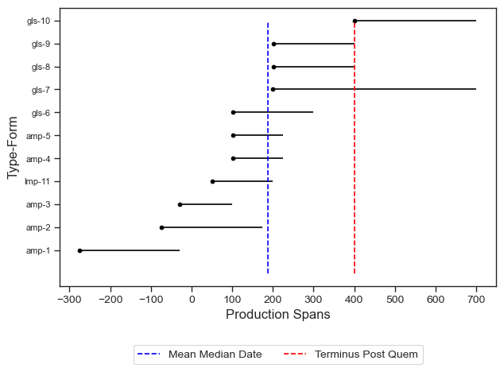

```python
KAGC_FUN.FC_DatePlt(a020, save_plot="Y", out_ti="Fig_7_6_A020_FCounts", fext=".pdf", Vlines= "Y", start = -300, stop = 800)
```

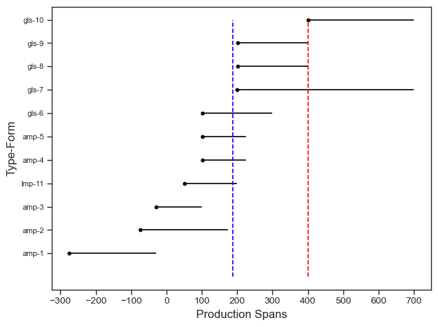

```python
FC_DatePlt_B(a020, save_plot="N", out_ti="A020_FCounts", fext=".png", Vlines= "Y", start = -300, stop = 800)
```

### MCLS TPQs

```python
a020.MCLS_TPQS()
```

|  | DU | name | cxn | mcls | Cat | diag | type1 | type2 | date1 | date3 | date4 | Dspan | MPDate | EAAD | EAAD-M |
| --- | --- | --- | --- | --- | --- | --- | --- | --- | --- | --- | --- | --- | --- | --- | --- |
| 1530 | A020 | TRA05 | TRA05-3 | lmp | None | Vessberg 13/14? | lamp | upper part | AD | 51.0 | 200.0 | 149.0 | 125.5 | 350.0 | 425.0 |
| 3026 | A020 | TRA05 | TRA05-3.1 | amp | None | Agora G199 | Agora G199 | H | AD | 101.0 | 225.0 | 124.0 | 163.0 | 300.0 | 387.5 |
| 2714 | A020 | TRA05 | TRA05-3.1 | gls | G17.158 | reshaped vessel | reshaped vessel | body | AD | 401.0 | 700.0 | 299.0 | 550.5 | 0.0 | 0.0 |

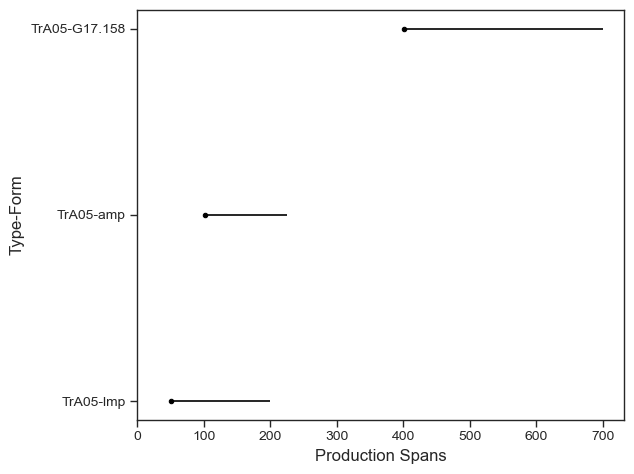

```python
KAGC_FUN.DU_MCLS_TPQ_Plt(a020, "N", "A020_MCLS_TPQS", ".png", start = 0, stop = 800)
```

#### Median Dates

```python
KAGC_FUN.MMDate(a020)
```

|  | mcls | MPDate |
| --- | --- | --- |
| 0 | amp | 83.5 |
| 1 | gls | 360.4 |
| 2 | lmp | 125.5 |
| 3 | mtl | NaN |
| 4 | pls | NaN |
| 5 | stn | NaN |

### DU A020 Summary

```python
a020.DUSmry()
```

|  | DU | TPQ | MMDate | Span | TForms | RForms | NRForms | NRF:RF | Dspan > 100 | Arch | Display | P.items | P.adorn | Tool | Production |
| --- | --- | --- | --- | --- | --- | --- | --- | --- | --- | --- | --- | --- | --- | --- | --- |
| 0 | A020 | 401.0 | 188 | 975.0 | 11 | 3 | 8 | 2.67 | 11 | True | True | False | False | False | True |

### Marker Groups

```python
a020.MKG1()
```

| type1 cxn | architectural member? | mortarium | moulding | painted plaster | tessera | All |
| --- | --- | --- | --- | --- | --- | --- |
| TRA05-3 | 1 | 1 | 1 | 1 | 0 | 4 |
| TRA05-3.1 | 0 | 0 | 0 | 1 | 1 | 2 |
| All | 1 | 1 | 1 | 2 | 1 | 6 |

### Faunal

```python
a020F = co.Faunal(art_db, KAGC_DUS.A020, "A020")
```

```python
a020F.faun()
```

|  | index | name | tr_tb | area | level | species | bone | cond | burnt | butchered | worked | freq | Comment | cxn | DU |
| --- | --- | --- | --- | --- | --- | --- | --- | --- | --- | --- | --- | --- | --- | --- | --- |

### DUs A019 A020 compared

```python
KAGC_Functions.common_subtypes(a019.FCounts().diag, a020.FCounts().diag)
```

```
{'Common subtypes:': {'AMRIT 77',
  'Agora G199',
  'Vessberg 13/14?',
  'bowl',
  'undiagnostic'},
 'Number of common subtypes:': 5}
```

```python
KAGC_Functions.common_subtypes(a019.cdu.type1.unique(), a020.cdu.type1.unique())
```

```
{'Common subtypes:': {'AMRIT 77',
  'Agora G199',
  'UnID',
  'bowl',
  'lamp',
  'painted plaster',
  'undiagnostic'},
 'Number of common subtypes:': 7}
```

```python
LateMat(a020, 400)
```

| col_0 | index | DU | mcls | diag | date3 | date4 | Dspan | MPDate | EAAD | idn | freq | Seq |
| --- | --- | --- | --- | --- | --- | --- | --- | --- | --- | --- | --- | --- |
| 6 | 8 | A020 | gls | tessera | 200.0 | 700.0 | 500.0 | 450.0 | 201.0 | gls-tessera-200.0-700.0 | 1 | 7 |
| 9 | 7 | A020 | gls | reshaped vessel | 401.0 | 700.0 | 299.0 | 550.5 | 0.0 | gls-reshaped vessel-401.0-700.0 | 1 | 10 |

```python
LateMat(a019, 400)
```

| col_0 | index | DU | mcls | diag | date3 | date4 | Dspan | MPDate | EAAD | idn | freq | Seq |
| --- | --- | --- | --- | --- | --- | --- | --- | --- | --- | --- | --- | --- |
| 10 | 9 | A019 | gls | undiagnostic | 301.0 | 700.0 | 399.0 | 500.5 | 99.0 | gls-undiagnostic-301.0-700.0 | 1 | 11 |
| 16 | 20 | A019 | num | coin | 301.0 | 500.0 | 199.0 | 400.5 | 99.0 | num-coin-301.0-500.0 | 1 | 17 |
| 19 | 18 | A019 | num | Honorius | 395.0 | 402.0 | 7.0 | 398.5 | 5.0 | num-Honorius-395.0-402.0 | 1 | 20 |
| 20 | 16 | A019 | num | Arcadius & Honorius | 400.0 | 408.0 | 8.0 | 404.0 | 0.0 | num-Arcadius & Honorius-400.0-408.0 | 1 | 21 |

# Area A Western Sector 2: Attritional Deposits

Apart from deposits associated with earthquake refuse cleanup, AWS also contains two DUs, DU A007 and A016 from TrA05 and TrA11 respectively, that we believe are derived from the early 20th-century archaeological excavations at the House of Eustolios and general erosion/wash from the acropolis respectively. The sediments from both DUs are loose and contain a high proportion of fist-sized rubble inclusions which are similar to the rubble that litters the slopes around the House of Eustolios from above TrA05 and TrA11. This section presents these DUs and their assemblage profiles.

## DU A007

```python
a007 = co.Context(KAGC_FUN.DU_Select(df, KAGC_DUS.A007, 'A007'), -24)
```

### Cat Nos

```python
a007.DUCatNos()
```

|  | cxn | mcls | diag | Cat | type1 | date3 | date4 |
| --- | --- | --- | --- | --- | --- | --- | --- |
| 3915 | TRA05-0 | bn | undiagnostic | VA01 | die | NaN | NaN |
| 3113 | TRA05-0 | fw | classical-hellenistic black glaze | FW020 | bowl | -500.0 | -201.0 |
| 3117 | TRA05-0 | fw | classical-hellenistic black glaze | FW021 | Shallow Plate | -500.0 | -201.0 |
| 3341 | TRA05-0 | fw | eastern sigillata a | FW036 | Large Bowl or Plate | -150.0 | 200.0 |
| 3365 | TRA05-0 | fw | eastern sigillata a form 23 | FW051 | Bowl | -100.0 | -50.0 |
| 3451 | TRA05-0 | fw | hellenistic color coated | FW073 | UnID | -300.0 | -101.0 |
| 3453 | TRA05-0 | fw | hellenistic color coated | FW074 | Jug | -300.0 | -101.0 |
| 3461 | TRA05-0 | fw | hellenistic color coated | FW075 | UnID | -300.0 | -101.0 |
| 3467 | TRA05-0 | fw | hellenistic color coated | FW079 | Bowl | -300.0 | -101.0 |
| 3468 | TRA05-0 | fw | hellenistic color coated | FW080 | Bowl | -300.0 | -101.0 |
| 3492 | TRA05-0 | fw | hellenistic fine ware | FW092 | Small, enclosed. | -300.0 | -1.0 |
| 3460 | TRA05-0 | fw | hellenistic inturned rim bowl | FW097 | Bowl | -300.0 | -101.0 |
| 3503 | TRA05-0 | fw | hellenistic inturned rim bowl | FW102 | Bowl | -300.0 | -101.0 |
| 3173 | TRA05-0 | fw | cypriot sigillata | FW113 | Bowl | -100.0 | 200.0 |
| 3174 | TRA05-0 | fw | cypriot sigillata | FW114 | Shallow Plate | -100.0 | 200.0 |
| 3175 | TRA05-0 | fw | cypriot sigillata | FW115 | UnID | -100.0 | 200.0 |
| 3176 | TRA05-0 | fw | cypriot sigillata | FW116 | Plate | -100.0 | 200.0 |
| 3177 | TRA05-0 | fw | cypriot sigillata | FW117 | Jug | -100.0 | 200.0 |
| 3295 | TRA05-0 | fw | early roman red slip, local | FW174 | Small thickwalled Bowl | -100.0 | 200.0 |
| 3788 | TRA05-0 | pls | None | PL38 | painted plaster | NaN | NaN |
| 3796 | TRA05-0 | pls | None | PL46 | painted plaster | NaN | NaN |

### FCounts

```python
a007.FCounts()
```

| col_0 | index | DU | mcls | diag | date3 | date4 | Dspan | MPDate | EAAD | idn | freq | Seq |
| --- | --- | --- | --- | --- | --- | --- | --- | --- | --- | --- | --- | --- |
| 0 | 0 | A007 | amp | Agora G199 | 101.0 | 225.0 | 124.0 | 163.0 | 400.0 | amp-Agora G199-101.0-225.0 | 1 | 1 |
| 1 | 1 | A007 | fw | classical-hellenistic black glaze | -500.0 | -201.0 | 299.0 | -350.5 | 1001.0 | fw-classical-hellenistic black glaze--500.0--201.0 | 7 | 2 |
| 2 | 10 | A007 | fw | medium coarse classical-hellenistic | -400.0 | -200.0 | 200.0 | -300.0 | 901.0 | fw-medium coarse classical-hellenistic--400.0--200.0 | 1 | 3 |
| 3 | 7 | A007 | fw | hellenistic color coated | -300.0 | -101.0 | 199.0 | -200.5 | 801.0 | fw-hellenistic color coated--300.0--101.0 | 10 | 4 |
| 4 | 8 | A007 | fw | hellenistic fine ware | -300.0 | -1.0 | 299.0 | -150.5 | 801.0 | fw-hellenistic fine ware--300.0--1.0 | 1 | 5 |
| 5 | 9 | A007 | fw | hellenistic inturned rim bowl | -300.0 | -101.0 | 199.0 | -200.5 | 801.0 | fw-hellenistic inturned rim bowl--300.0--101.0 | 7 | 6 |
| 6 | 11 | A007 | fw | medium coarse hellenistic | -300.0 | -1.0 | 299.0 | -150.5 | 801.0 | fw-medium coarse hellenistic--300.0--1.0 | 1 | 7 |
| 7 | 5 | A007 | fw | eastern sigillata a | -150.0 | 200.0 | 350.0 | 25.0 | 651.0 | fw-eastern sigillata a--150.0-200.0 | 2 | 8 |
| 8 | 2 | A007 | fw | cypriot sigillata | -100.0 | 200.0 | 300.0 | 50.0 | 601.0 | fw-cypriot sigillata--100.0-200.0 | 5 | 9 |
| 9 | 4 | A007 | fw | early roman red slip, local | -100.0 | 200.0 | 300.0 | 50.0 | 601.0 | fw-early roman red slip, local--100.0-200.0 | 1 | 10 |
| 10 | 6 | A007 | fw | eastern sigillata a form 23 | -100.0 | -50.0 | 50.0 | -75.0 | 601.0 | fw-eastern sigillata a form 23--100.0--50.0 | 1 | 11 |
| 11 | 3 | A007 | fw | cypriot sigillata form p40 | 75.0 | 150.0 | 75.0 | 112.5 | 426.0 | fw-cypriot sigillata form p40-75.0-150.0 | 1 | 12 |
| 12 | 17 | A007 | gls | dish or bowl | 1.0 | 100.0 | 99.0 | 50.5 | 500.0 | gls-dish or bowl-1.0-100.0 | 1 | 13 |
| 13 | 19 | A007 | gls | stemmed goblet or cup | 1.0 | 300.0 | 299.0 | 150.5 | 500.0 | gls-stemmed goblet or cup-1.0-300.0 | 1 | 14 |
| 14 | 12 | A007 | gls | beaker | 101.0 | 300.0 | 199.0 | 200.5 | 400.0 | gls-beaker-101.0-300.0 | 1 | 15 |
| 15 | 14 | A007 | gls | bottle | 101.0 | 300.0 | 199.0 | 200.5 | 400.0 | gls-bottle-101.0-300.0 | 1 | 16 |
| 16 | 16 | A007 | gls | cup | 101.0 | 300.0 | 199.0 | 200.5 | 400.0 | gls-cup-101.0-300.0 | 1 | 17 |
| 17 | 20 | A007 | gls | undiagnostic | 101.0 | 500.0 | 399.0 | 300.5 | 400.0 | gls-undiagnostic-101.0-500.0 | 1 | 18 |
| 18 | 15 | A007 | gls | bottle | 201.0 | 400.0 | 199.0 | 300.5 | 300.0 | gls-bottle-201.0-400.0 | 1 | 19 |
| 19 | 13 | A007 | gls | beaker | 301.0 | 500.0 | 199.0 | 400.5 | 200.0 | gls-beaker-301.0-500.0 | 1 | 20 |
| 20 | 18 | A007 | gls | hollow stemmed lamp | 501.0 | 700.0 | 199.0 | 600.5 | 0.0 | gls-hollow stemmed lamp-501.0-700.0 | 1 | 21 |
| 21 | 21 | A007 | lmp | UnID | 1.0 | 200.0 | 199.0 | 100.5 | 500.0 | lmp-UnID-1.0-200.0 | 2 | 22 |
| 22 | 22 | A007 | lmp | Vessberg 11/14? | 1.0 | 200.0 | 199.0 | 100.5 | 500.0 | lmp-Vessberg 11/14?-1.0-200.0 | 1 | 23 |

### MCLS TPQs

```python
a007.MCLS_TPQS()
```

|  | DU | name | cxn | mcls | Cat | diag | type1 | type2 | date1 | date3 | date4 | Dspan | MPDate | EAAD | EAAD-M |
| --- | --- | --- | --- | --- | --- | --- | --- | --- | --- | --- | --- | --- | --- | --- | --- |
| 1519 | A007 | TRA05 | TRA05-0 | lmp | None | UnID | lamp | nozzle | AD | 1.0 | 200.0 | 199.0 | 100.5 | 500.0 | 500.0 |
| 3279 | A007 | TRA05 | TRA05-0 | fw | None | cypriot sigillata form p40 | Basin or Crater. | rim | AD | 75.0 | 150.0 | 75.0 | 112.5 | 426.0 | 488.0 |
| 3048 | A007 | TRA05 | TRA05-0 | amp | None | Agora G199 | Agora G199 | R | AD | 101.0 | 225.0 | 124.0 | 163.0 | 400.0 | 437.5 |
| 2209 | A007 | TRA05-BLK | TRA05-BLK-0 | gls | None | hollow stemmed lamp | hollow stemmed lamp | rim/body | AD | 501.0 | 700.0 | 199.0 | 600.5 | 0.0 | 0.0 |

#### Median Dates

```python
KAGC_FUN.MMDate(a007)
```

|  | mcls | MPDate |
| --- | --- | --- |
| 0 | amp | 163.000000 |
| 1 | bn | NaN |
| 2 | fw | -164.202703 |
| 3 | gls | 267.166667 |
| 4 | lmp | 100.500000 |
| 5 | pls | NaN |
| 6 | stn | NaN |

### Marker Groups

```python
a007.MKG1()
```

| type1 cxn | painted plaster | revetment | All |
| --- | --- | --- | --- |
| TRA05-0 | 2 | 5 | 7 |
| All | 2 | 5 | 7 |

```python
a007.MKG3()
```

| type1 cxn | Agora G199 | Basin or Crater. | Basin or large open vessel | Bowl | Jug | Large Bowl or Plate | Large vessel | Plate | Plate or Bowl | Shallow Bowl or Plate | Shallow Plate | Small thickwalled Bowl | Small, enclosed. | UnID | beaker | bottle | bowl | cup | dish or bowl | hollow stemmed lamp | lamp | stemmed goblet or cup | All |
| --- | --- | --- | --- | --- | --- | --- | --- | --- | --- | --- | --- | --- | --- | --- | --- | --- | --- | --- | --- | --- | --- | --- | --- |
| TRA05-0 | 1 | 1 | 1 | 13 | 2 | 1 | 1 | 4 | 3 | 1 | 2 | 1 | 1 | 6 | 0 | 1 | 1 | 1 | 1 | 0 | 3 | 0 | 45 |
| TRA05-BLK-0 | 0 | 0 | 0 | 0 | 0 | 0 | 0 | 0 | 0 | 0 | 0 | 0 | 0 | 0 | 2 | 1 | 0 | 0 | 0 | 1 | 0 | 1 | 5 |
| All | 1 | 1 | 1 | 13 | 2 | 1 | 1 | 4 | 3 | 1 | 2 | 1 | 1 | 6 | 2 | 2 | 1 | 1 | 1 | 1 | 3 | 1 | 50 |

### DU A007 Summary

```python
a007.DUSmry()
```

|  | DU | TPQ | MMDate | Span | TForms | RForms | NRForms | NRF:RF | Dspan > 100 | Arch | Display | P.items | P.adorn | Tool | Production |
| --- | --- | --- | --- | --- | --- | --- | --- | --- | --- | --- | --- | --- | --- | --- | --- |
| 0 | A007 | 501.0 | -64 | 1200.0 | 23 | 10 | 13 | 1.3 | 20 | True | True | False | False | False | False |

### Plots

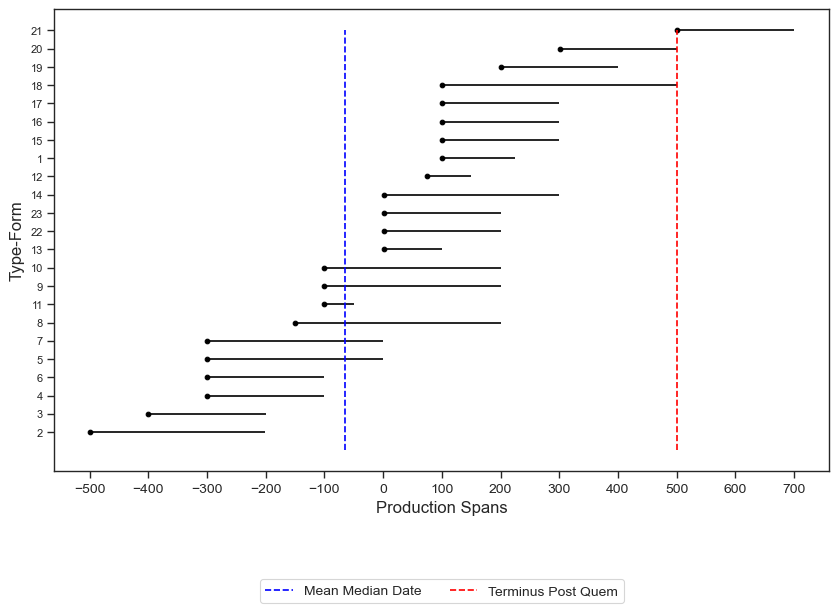

```python
KAGC_FUN.FC_DatePlt(a007, "Y", "N", " ", " ", start = -500, stop = 800)
```

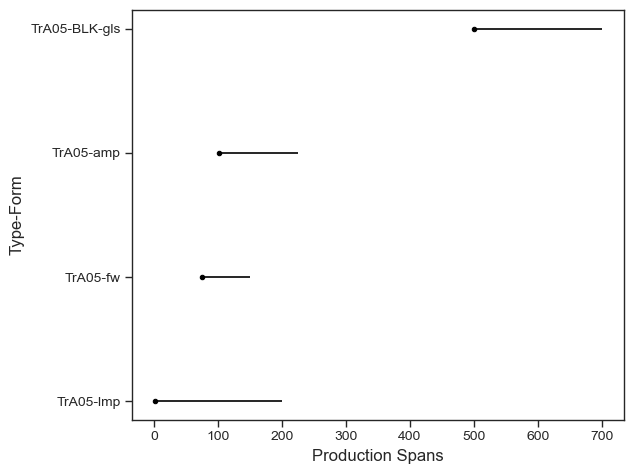

```python
KAGC_FUN.DU_MCLS_TPQ_Plt(a007, "N", " ", " ", start = 0, stop = 800)
```

### Faunal

```python
a007f = co.Faunal(art_db, KAGC_DUS.A007, "A007")
```

```python
a007f.BBW()
```

|  | index | name | tr_tb | area | level | species | bone | cond | burnt | butchered | worked | freq | Comment | cxn | DU |
| --- | --- | --- | --- | --- | --- | --- | --- | --- | --- | --- | --- | --- | --- | --- | --- |
| 438 | 438.0 | TRA05 | TR | A | 0 | bos-sized | unid | f | n | y | n | 1.0 | None | TRA05-0 | A007 |

## DU A016

```python
a016 = co.Context(KAGC_FUN.DU_Select(df, KAGC_DUS.A016, 'A016'), -24)
```

### Cat Nos

```python
a016.DUCatNos()
```

|  | cxn | mcls | diag | Cat | type1 | date3 | date4 |
| --- | --- | --- | --- | --- | --- | --- | --- |
| 3746 | TRA11-0 | amp | Rhodian stamped handle | SA05 | stamped-fabricant | -200.0 | -101.0 |
| 3747 | TRA11-0 | amp | Rhodian stamped handle | SA06 | stamped-eponym | -200.0 | -100.0 |
| 3741 | TRA11-0 | lmp | mold Vessberg 18b? | LP54 | lamp mold | 301.0 | 500.0 |
| 3610 | TRA11-0 | stn | None | ST13 | mortarium | NaN | NaN |
| 3713 | TRA11-0 | stn | None | ST33 | statuary base | NaN | NaN |
| 107 | TRA11-0 | trc | figurine | TC16 | figurine | -312.0 | -100.0 |

### FCounts

```python
a016.FCounts()
```

| col_0 | index | DU | mcls | diag | date3 | date4 | Dspan | MPDate | EAAD | idn | freq | Seq |
| --- | --- | --- | --- | --- | --- | --- | --- | --- | --- | --- | --- | --- |
| 0 | 0 | A016 | amp | Rhodian stamped handle | -200.0 | -101.0 | 99.0 | -150.5 | 1001.0 | amp-Rhodian stamped handle--200.0--101.0 | 1 | 1 |
| 1 | 1 | A016 | amp | Rhodian stamped handle | -200.0 | -100.0 | 100.0 | -150.0 | 1001.0 | amp-Rhodian stamped handle--200.0--100.0 | 1 | 2 |
| 2 | 3 | A016 | gls | dish or bowl | 101.0 | 300.0 | 199.0 | 200.5 | 700.0 | gls-dish or bowl-101.0-300.0 | 1 | 3 |
| 3 | 8 | A016 | gls | unguentarium | 101.0 | 300.0 | 199.0 | 200.5 | 700.0 | gls-unguentarium-101.0-300.0 | 1 | 4 |
| 4 | 4 | A016 | gls | dish or bowl | 201.0 | 400.0 | 199.0 | 300.5 | 600.0 | gls-dish or bowl-201.0-400.0 | 1 | 5 |
| 5 | 2 | A016 | gls | cup or bowl | 401.0 | 700.0 | 299.0 | 550.5 | 400.0 | gls-cup or bowl-401.0-700.0 | 1 | 6 |
| 6 | 6 | A016 | gls | goblet | 401.0 | 600.0 | 199.0 | 500.5 | 400.0 | gls-goblet-401.0-600.0 | 1 | 7 |
| 7 | 5 | A016 | gls | flask or jar | 701.0 | 1000.0 | 299.0 | 850.5 | 100.0 | gls-flask or jar-701.0-1000.0 | 1 | 8 |
| 8 | 7 | A016 | gls | jug or flask | 801.0 | 1000.0 | 199.0 | 900.5 | 0.0 | gls-jug or flask-801.0-1000.0 | 1 | 9 |
| 9 | 9 | A016 | lmp | Vessberg 16 | 201.0 | 400.0 | 199.0 | 300.5 | 600.0 | lmp-Vessberg 16-201.0-400.0 | 1 | 10 |
| 10 | 10 | A016 | lmp | Vessberg 18a | 201.0 | 400.0 | 199.0 | 300.5 | 600.0 | lmp-Vessberg 18a-201.0-400.0 | 1 | 11 |
| 11 | 11 | A016 | lmp | Vessberg 18a? | 201.0 | 400.0 | 199.0 | 300.5 | 600.0 | lmp-Vessberg 18a?-201.0-400.0 | 2 | 12 |
| 12 | 12 | A016 | lmp | mold Vessberg 18b? | 301.0 | 500.0 | 199.0 | 400.5 | 500.0 | lmp-mold Vessberg 18b?-301.0-500.0 | 1 | 13 |
| 13 | 13 | A016 | trc | figurine | -312.0 | -100.0 | 212.0 | -206.0 | 1113.0 | trc-figurine--312.0--100.0 | 1 | 14 |

```python
a016.FCounts()[a016.FCounts().mcls=='gls'].MPDate.mean()
```

```
500.5
```

### MCLS TPQs

```python
a016.MCLS_TPQS()
```

|  | DU | name | cxn | mcls | Cat | diag | type1 | type2 | date1 | date3 | date4 | Dspan | MPDate | EAAD | EAAD-M |
| --- | --- | --- | --- | --- | --- | --- | --- | --- | --- | --- | --- | --- | --- | --- | --- |
| 107 | A016 | TRA11 | TRA11-0 | trc | TC16 | figurine | figurine | animal leg | BC | -312.0 | -100.0 | 212.0 | -206.0 | 1113.0 | 1106.5 |
| 3746 | A016 | TRA11 | TRA11-0 | amp | SA05 | Rhodian stamped handle | stamped-fabricant | H/STAMP | BC | -200.0 | -101.0 | 99.0 | -150.5 | 1001.0 | 1051.0 |
| 3741 | A016 | TR | TRA11-0 | lmp | LP54 | mold Vessberg 18b? | lamp mold | None | AD | 301.0 | 500.0 | 199.0 | 400.5 | 500.0 | 500.0 |
| 2186 | A016 | TRA11 | TRA11-0 | gls | None | jug or flask | jug or flask | base | AD | 801.0 | 1000.0 | 199.0 | 900.5 | 0.0 | 0.0 |

#### Median Dates

```python
KAGC_FUN.MMDate(a016)
```

|  | mcls | MPDate |
| --- | --- | --- |
| 0 | amp | -150.25 |
| 1 | gls | 500.50 |
| 2 | jwl | NaN |
| 3 | lmp | 320.50 |
| 4 | pls | NaN |
| 5 | stn | NaN |
| 6 | trc | -206.00 |

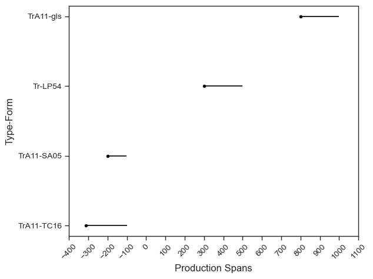

```python
KAGC_FUN.DU_MCLS_TPQ_Plt(a016, "N", "", "", start = -400, stop = 1200)
```

### DU A016 Summary

```python
a016.DUSmry()
```

|  | DU | TPQ | MMDate | Span | TForms | RForms | NRForms | NRF:RF | Dspan > 100 | Arch | Display | P.items | P.adorn | Tool | Production |
| --- | --- | --- | --- | --- | --- | --- | --- | --- | --- | --- | --- | --- | --- | --- | --- |
| 0 | A016 | 801.0 | 307 | 1312.0 | 14 | 3 | 11 | 3.67 | 12 | True | True | False | True | False | True |

### Marker Groups

```python
a016.MKG1()
```

| type1 cxn | lamp mold | mortarium | painted plaster | revetment | statuary base | All |
| --- | --- | --- | --- | --- | --- | --- |
| TRA11-0 | 1 | 1 | 7 | 1 | 1 | 11 |
| All | 1 | 1 | 7 | 1 | 1 | 11 |

```python
a016.MKG2()
```

| type1 cxn | figurine | hairpin | All |
| --- | --- | --- | --- |
| TRA11-0 | 1 | 1 | 2 |
| All | 1 | 1 | 2 |

```python
a016.MKG3()
```

| type1 cxn | dish or bowl | flask or jar | goblet | jug or flask | lamp | stamped-eponym | stamped-fabricant | unguentarium | All |
| --- | --- | --- | --- | --- | --- | --- | --- | --- | --- |
| TRA11-0 | 2 | 1 | 1 | 1 | 4 | 1 | 1 | 1 | 12 |
| All | 2 | 1 | 1 | 1 | 4 | 1 | 1 | 1 | 12 |

```python
a016f = co.Faunal(art_db, KAGC_DUS.A016, "A016")
```

```python
a016f.BBW()
```

|  | index | name | tr_tb | area | level | species | bone | cond | burnt | butchered | worked | freq | Comment | cxn | DU |
| --- | --- | --- | --- | --- | --- | --- | --- | --- | --- | --- | --- | --- | --- | --- | --- |
| 608 | 608.0 | TRA11 | TR | A | 0 | bos | horn core | f | n | n | y | 1.0 | None | TRA11-0 | A016 |

```python
a016f.FxTB()
```

| species cxn | bird | bos | bos/equus | equus asinus | equus caballus | ovis-capra | sus | unid | All |
| --- | --- | --- | --- | --- | --- | --- | --- | --- | --- |
| TRA11-0 | 1.0 | 2.0 | 15.0 | 1.0 | 14.0 | 1.0 | 1.0 | 21.0 | 56.0 |
| All | 1.0 | 2.0 | 15.0 | 1.0 | 14.0 | 1.0 | 1.0 | 21.0 | 56.0 |

```python
x = [a016.MKG1().All.max(), a016.MKG2().All.max(), a016.MKG3().All.max()]

for i in x:
    round(i*100/sum(x), 2)
```